# Conjoint Analysis - Servicio de Hospedaje

Juan Spadaro - MiM + Analytics (UTDT)

Octubre de 2022

## I. Diseño del estudio

El mundo del entretenimiento, placeres y turismo se encuentra actualmente envuelto en una gran revolución. Lejos ha quedado aquel producto o servicio masivo. En la actualidad la personalización es la gran aliada, y el servicio de hospedaje es un claro ejemplo de ello. En el presente trabajo se intentará determinar las preferencias de los potenciales consumidores de dicho servicio de hospedaje.

Recordando que el mismo cuenta con un conjunto de atributos con diversos niveles asociados, a continuación, se procede a detallar los mismos:

- **Precio por noche por persona:** sin duda es un atributo sumamente importante a la hora de decidir una opción por parte del consumidor. En algunos momentos es posible que estemos dispuestos a pagar un precio muy alto, mientras en algunos otros es posible que resignemos calidad por un precio bastante bajo. Los niveles definidos para dicho atributo son:
  - $4.500
  - $8.000
  - $25.000
- **Ubicación del centro:** es un atributo que posiblemente influya en la disponibilidad a pagar del consumidor dependiendo de sus preferencias. Los niveles definidos para dicho atributo son:
  - 0 km
  - 5 km
  - 20 km
- **Incluye desayuno:** con altas probabilidades, seguramente sea un atributo clave a la hora de elegir el producto por parte del consumidor. Principalmente porque la falta de este tipo de servicio reflejará una disponibilidad a pagar menor debido a que podría ver a este faltante como un costo adicional al momento de realizar el viaje. Por este motivo, resulta interesante su inclusión en el análisis. Los niveles definidos para dicho atributo son:
  - Si (en caso de que el hospedaje incluya desayuno)
  - No (caso contrario)
- **Incluye pileta:** este es un atributo que sin duda hace una diferencia a la contratar un hospedaje, aunque quizás sea un poco más fino en términos de importancia en las preferencias del consumidor, que los demás propuestos hasta el momento. Es algo que a un consumidor promedio posiblemente no le impacte en la elección, pero para un determinado clúster de clientes sea un factor determinante. Los niveles definidos para dicho atributo son:
  - Si (en caso de que el hospedaje incluya pileta)
  - No (caso contrario)

¿Cuál es el producto ideal para un cliente? ¿Cuál es el precio que un consumir estaría dispuesto a pagar por cada atributo? El cliente por lo general no puede cuantificar cada atributo y monetizarlo de forma independiente. Esta metodología se la conoce como **análisis conjunto**. El objetivo es el de identificar la combinación de atributos óptima, que maximicen un cierto objetivo, como puede ser el de maximizar las utilidades por venta, o aumentar la participación de mercado (market share).

Para poder lograr estos objetivos, necesitamos información de los consumidores. Lo que hacemos es ayudar al cliente a brindar información respecto a cuánto valora cada atributo. Con ello, se considera a las preferencias de los consumidores para diseñar el producto óptimo según el tipo de cliente.

Voy a ofrecerle distintos productos al cliente, el cual le va a asignar una utilidad a cada disposición de los productos (con sus atributos alternativos). Luego para comparar entre dos productos, simplemente va a comparar la utilidad que le brinda cada uno. Estamos asumiendo pura racionalidad por parte de los consumidores.

Para obtener las preferencias de los consumidores, en su caso más básico, es mediante una encuesta con algunas opciones y el cliente puede puntuar de 1 a 9 estrellas las diferentes alternativas. Disponemos de 3 posibles precios, 3 posibles ubicaciones del centro, 2 alternativas de si incluye o no desayuno y 2 alternativas de si incluye o no pileta. Esto no da un total de 4 atributos con 3, 3, 2 y 2 niveles (3 x 3 x 2 x 2 = 36 posibles perfiles) de diferentes combinaciones de los atributos que nos darán una definición de producto.

Sería imposible presentar a los encuestados una encuesta de 36 preguntas y que ellos puntúen del 1 al 9 todos los escenarios. Posiblemente ninguno de ellos o muy pocos logren terminar las mismas, y las últimas sería totalmente al azar por el cansancio de los individuos. Para ellos es que se seleccionan perfiles determinados de los 36 posibles para presentar a los encuestados.

Aquí es donde aparece la teoría de diseño experimental, que nos determina que perfiles debo consultar e incluir en el cuestionario. El subconjunto de perfiles que están incluidos en el cuestionario permite recolectar la misma información que *como si* incluyéramos la totalidad de estos. Esto nos asegura que no perdemos mucha información, ya que se seleccionan los productos con el mayor número de diferencias entre ellos.

Para la selección de los perfiles a evaluar se usó el código en R provisto en clase con algunas modificaciones. De los 36 escenarios se presentaron finalmente 12, que fueron los que se obtuvieron del código. Estos diseños experimentales permiten la reducción del número total de perfiles que deben ser valorados por cada encuestado a modo de simplificar sin una pérdida de información.

Bajo este esquema, los perfiles que quedaron seleccionados aleatoriamente fueron:

```r
#Code to generate factorial orthogonal designs
setwd("C:/Others/Master in Management + Analytics/MATERIAS/Módulo 03/Ventas y Marketing/TP Final/")
library(conjoint)
library(openxlsx)
c <- expand.grid(
  `Ubicación del centro` <- c("0km", "5km", "20km"),
  Precio <- c("$4500", "$8000","$25000"),
  `Incluye desayuno` <- c("si", "no"),
  `Incluye pileta` <- c("si", "no"))

names(c) <- c("Ubicación del centro", "Precio",
              "Incluye desayuno", "Incluye pileta")

set.seed(1)
design <- caFactorialDesign(data=c, type="fractional")
code <- caEncodedDesign(design)
encodedorthodesign <- data.frame(design, code)

write.xlsx(encodedorthodesign, "encodedorthodesign.xlsx")
```

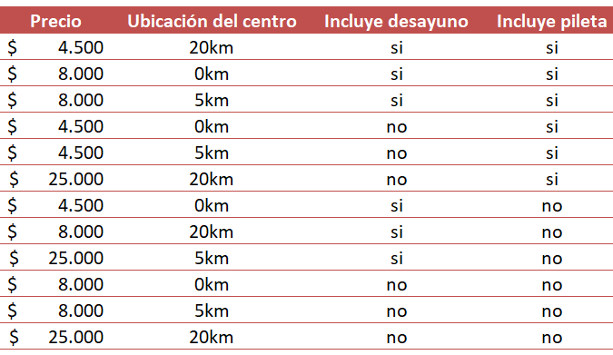

En base a dicha tabla con la combinación de los diferentes niveles de atributos es que se plantea cada uno de los 12 modelos en la cual el usuario seleccionó entre 1 (muy malo) y 9 (excelente) la compra del servicio con esos niveles de atributos determinados.

## II. Recolección de datos

La encuesta fue realizada a través de y se encuentra disponible online en ingresando a través del siguiente link: [Encuesta de Servicio de Hospedaje](https://s.surveyplanet.com/3wkl8v1v).

Enviando la misma mediante WhatsApp a diferentes grupos y pidiendo la difusión de esta, se logró obtener **47 respuestas**, en donde el promedio de respuesta para completar la misma por parte de los encuestados fue de 3 minutos 12 segundos.

## III. Análisis de datos

**1. Análisis de regresión: estimando los valores parciales de cada uno de sus encuestados**

Vamos a asumir que un producto entrega utilidad a los consumidores. Y que la utilidad que le entrega el producto depende de la configuración de este, es decir, de los niveles que tomen sus atributos, que impactan en la función de utilidad de manera aditiva. Luego de analizar esto, le va a asignar un número a esa utilidad. Así es que, comparando esta utilidad de manera puramente racional, el consumir siempre va a elegir aquel producto que le produzca una mayor utilidad.

En este caso, la función de utilidad o nuestro modelo sería el siguiente:

$$U=
u_0+u_1 (precio)+u_2 (ubicación)+u_3 (desayuno)+u_4 (pileta)+u_e$$

Mediante una regresión lineal vamos a estimar el modelo propuesto arriba. De esta forma obtenemos las estimadores de cada uno de los atributos.

Para trabajar los distintos modelos y sus atributos, se utilizarán variables dummys. Transformamos cada uno de los atributos en k-1 columnas. Donde aparece el 1 implica que el atributo está presente en ese nivel, 0 para el caso contrario. Cuando los k-1 niveles son 0, implica que el atributo de nivel k (nivel de referencia) es el presente.

A continuación, tras haber realizado una regresión lineal para cada uno de los encuestados (véase el código asociado para mayores detalles) se puede visualizar los coeficientes correspondientes de cada uno:

```r
library(readxl)
library(tidyverse)
library(openxlsx)
library(ggplot2)

# Clear the global environment
rm(list = ls())
options(scipen=10)

# Set the path where the raw files are at
setwd("C:/Others/Master in Management + Analytics/MATERIAS/Módulo 03/Ventas y Marketing/TP Final/")

# Upload the cellphone's preference data
data <- read_excel("Encuesta Servicio de Hospedaje (resultados).xlsx",sheet = 2)

variables_factor <- c("Modelo","Precio4500","Precio8000",
                      "Precio25000", "Distancia0km", "Distancia5km","Distancia20km",
                      "Desayuno","Pileta")

data[,variables_factor] <- lapply(data[,variables_factor], as.factor)

# Run a linear regression model of the preference as a function of the product's attributes levels
linear_model <- lm(formula = Utilidad ~ Precio4500 + Precio8000 + Distancia0km + Distancia5km + Desayuno + Pileta, data = data)
linear_model_ind1 <- lm(formula = Utilidad ~ Precio4500 + Precio8000 + Distancia0km + Distancia5km + Desayuno + Pileta, data = data%>%filter(ID_usuario==1))
linear_model_ind2 <- lm(formula = Utilidad ~ Precio4500 + Precio8000 + Distancia0km + Distancia5km + Desayuno + Pileta, data = data%>%filter(ID_usuario==2))
linear_model_ind3 <- lm(formula = Utilidad ~ Precio4500 + Precio8000 + Distancia0km + Distancia5km + Desayuno + Pileta, data = data%>%filter(ID_usuario==3))
linear_model_ind4 <- lm(formula = Utilidad ~ Precio4500 + Precio8000 + Distancia0km + Distancia5km + Desayuno + Pileta, data = data%>%filter(ID_usuario==4))
linear_model_ind5 <- lm(formula = Utilidad ~ Precio4500 + Precio8000 + Distancia0km + Distancia5km + Desayuno + Pileta, data = data%>%filter(ID_usuario==5))
linear_model_ind6 <- lm(formula = Utilidad ~ Precio4500 + Precio8000 + Distancia0km + Distancia5km + Desayuno + Pileta, data = data%>%filter(ID_usuario==6))
linear_model_ind7 <- lm(formula = Utilidad ~ Precio4500 + Precio8000 + Distancia0km + Distancia5km + Desayuno + Pileta, data = data%>%filter(ID_usuario==7))
linear_model_ind8 <- lm(formula = Utilidad ~ Precio4500 + Precio8000 + Distancia0km + Distancia5km + Desayuno + Pileta, data = data%>%filter(ID_usuario==8))
linear_model_ind9 <- lm(formula = Utilidad ~ Precio4500 + Precio8000 + Distancia0km + Distancia5km + Desayuno + Pileta, data = data%>%filter(ID_usuario==9))
linear_model_ind10 <- lm(formula = Utilidad ~ Precio4500 + Precio8000 + Distancia0km + Distancia5km + Desayuno + Pileta, data = data%>%filter(ID_usuario==10))
linear_model_ind11 <- lm(formula = Utilidad ~ Precio4500 + Precio8000 + Distancia0km + Distancia5km + Desayuno + Pileta, data = data%>%filter(ID_usuario==11))
linear_model_ind12 <- lm(formula = Utilidad ~ Precio4500 + Precio8000 + Distancia0km + Distancia5km + Desayuno + Pileta, data = data%>%filter(ID_usuario==12))
linear_model_ind13 <- lm(formula = Utilidad ~ Precio4500 + Precio8000 + Distancia0km + Distancia5km + Desayuno + Pileta, data = data%>%filter(ID_usuario==13))
linear_model_ind14 <- lm(formula = Utilidad ~ Precio4500 + Precio8000 + Distancia0km + Distancia5km + Desayuno + Pileta, data = data%>%filter(ID_usuario==14))
linear_model_ind15 <- lm(formula = Utilidad ~ Precio4500 + Precio8000 + Distancia0km + Distancia5km + Desayuno + Pileta, data = data%>%filter(ID_usuario==15))
linear_model_ind16 <- lm(formula = Utilidad ~ Precio4500 + Precio8000 + Distancia0km + Distancia5km + Desayuno + Pileta, data = data%>%filter(ID_usuario==16))
linear_model_ind17 <- lm(formula = Utilidad ~ Precio4500 + Precio8000 + Distancia0km + Distancia5km + Desayuno + Pileta, data = data%>%filter(ID_usuario==17))
linear_model_ind18 <- lm(formula = Utilidad ~ Precio4500 + Precio8000 + Distancia0km + Distancia5km + Desayuno + Pileta, data = data%>%filter(ID_usuario==18))
linear_model_ind19 <- lm(formula = Utilidad ~ Precio4500 + Precio8000 + Distancia0km + Distancia5km + Desayuno + Pileta, data = data%>%filter(ID_usuario==19))
linear_model_ind20 <- lm(formula = Utilidad ~ Precio4500 + Precio8000 + Distancia0km + Distancia5km + Desayuno + Pileta, data = data%>%filter(ID_usuario==20))
linear_model_ind21 <- lm(formula = Utilidad ~ Precio4500 + Precio8000 + Distancia0km + Distancia5km + Desayuno + Pileta, data = data%>%filter(ID_usuario==21))
linear_model_ind22 <- lm(formula = Utilidad ~ Precio4500 + Precio8000 + Distancia0km + Distancia5km + Desayuno + Pileta, data = data%>%filter(ID_usuario==22))
linear_model_ind23 <- lm(formula = Utilidad ~ Precio4500 + Precio8000 + Distancia0km + Distancia5km + Desayuno + Pileta, data = data%>%filter(ID_usuario==23))
linear_model_ind24 <- lm(formula = Utilidad ~ Precio4500 + Precio8000 + Distancia0km + Distancia5km + Desayuno + Pileta, data = data%>%filter(ID_usuario==24))
linear_model_ind25 <- lm(formula = Utilidad ~ Precio4500 + Precio8000 + Distancia0km + Distancia5km + Desayuno + Pileta, data = data%>%filter(ID_usuario==25))
linear_model_ind26 <- lm(formula = Utilidad ~ Precio4500 + Precio8000 + Distancia0km + Distancia5km + Desayuno + Pileta, data = data%>%filter(ID_usuario==26))
linear_model_ind27 <- lm(formula = Utilidad ~ Precio4500 + Precio8000 + Distancia0km + Distancia5km + Desayuno + Pileta, data = data%>%filter(ID_usuario==27))
linear_model_ind28 <- lm(formula = Utilidad ~ Precio4500 + Precio8000 + Distancia0km + Distancia5km + Desayuno + Pileta, data = data%>%filter(ID_usuario==28))
linear_model_ind29 <- lm(formula = Utilidad ~ Precio4500 + Precio8000 + Distancia0km + Distancia5km + Desayuno + Pileta, data = data%>%filter(ID_usuario==29))
linear_model_ind30 <- lm(formula = Utilidad ~ Precio4500 + Precio8000 + Distancia0km + Distancia5km + Desayuno + Pileta, data = data%>%filter(ID_usuario==30))
linear_model_ind31 <- lm(formula = Utilidad ~ Precio4500 + Precio8000 + Distancia0km + Distancia5km + Desayuno + Pileta, data = data%>%filter(ID_usuario==31))
linear_model_ind32 <- lm(formula = Utilidad ~ Precio4500 + Precio8000 + Distancia0km + Distancia5km + Desayuno + Pileta, data = data%>%filter(ID_usuario==32))
linear_model_ind33 <- lm(formula = Utilidad ~ Precio4500 + Precio8000 + Distancia0km + Distancia5km + Desayuno + Pileta, data = data%>%filter(ID_usuario==33))
linear_model_ind34 <- lm(formula = Utilidad ~ Precio4500 + Precio8000 + Distancia0km + Distancia5km + Desayuno + Pileta, data = data%>%filter(ID_usuario==34))
linear_model_ind35 <- lm(formula = Utilidad ~ Precio4500 + Precio8000 + Distancia0km + Distancia5km + Desayuno + Pileta, data = data%>%filter(ID_usuario==35))
linear_model_ind36 <- lm(formula = Utilidad ~ Precio4500 + Precio8000 + Distancia0km + Distancia5km + Desayuno + Pileta, data = data%>%filter(ID_usuario==36))
linear_model_ind37 <- lm(formula = Utilidad ~ Precio4500 + Precio8000 + Distancia0km + Distancia5km + Desayuno + Pileta, data = data%>%filter(ID_usuario==37))
linear_model_ind38 <- lm(formula = Utilidad ~ Precio4500 + Precio8000 + Distancia0km + Distancia5km + Desayuno + Pileta, data = data%>%filter(ID_usuario==38))
linear_model_ind39 <- lm(formula = Utilidad ~ Precio4500 + Precio8000 + Distancia0km + Distancia5km + Desayuno + Pileta, data = data%>%filter(ID_usuario==39))
linear_model_ind40 <- lm(formula = Utilidad ~ Precio4500 + Precio8000 + Distancia0km + Distancia5km + Desayuno + Pileta, data = data%>%filter(ID_usuario==40))
linear_model_ind41 <- lm(formula = Utilidad ~ Precio4500 + Precio8000 + Distancia0km + Distancia5km + Desayuno + Pileta, data = data%>%filter(ID_usuario==41))
linear_model_ind42 <- lm(formula = Utilidad ~ Precio4500 + Precio8000 + Distancia0km + Distancia5km + Desayuno + Pileta, data = data%>%filter(ID_usuario==42))
linear_model_ind43 <- lm(formula = Utilidad ~ Precio4500 + Precio8000 + Distancia0km + Distancia5km + Desayuno + Pileta, data = data%>%filter(ID_usuario==43))
linear_model_ind44 <- lm(formula = Utilidad ~ Precio4500 + Precio8000 + Distancia0km + Distancia5km + Desayuno + Pileta, data = data%>%filter(ID_usuario==44))
linear_model_ind45 <- lm(formula = Utilidad ~ Precio4500 + Precio8000 + Distancia0km + Distancia5km + Desayuno + Pileta, data = data%>%filter(ID_usuario==45))
linear_model_ind46 <- lm(formula = Utilidad ~ Precio4500 + Precio8000 + Distancia0km + Distancia5km + Desayuno + Pileta, data = data%>%filter(ID_usuario==46))
linear_model_ind47 <- lm(formula = Utilidad ~ Precio4500 + Precio8000 + Distancia0km + Distancia5km + Desayuno + Pileta, data = data%>%filter(ID_usuario==47))
```

```r
coeff_1 <- linear_model_ind1$coefficients;  id_1 = coeff_1
coeff_2 <- linear_model_ind2$coefficients;  id_2 = coeff_2
coeff_3 <- linear_model_ind3$coefficients;  id_3 = coeff_3
coeff_4 <- linear_model_ind4$coefficients;  id_4 = coeff_4
coeff_5 <- linear_model_ind5$coefficients;  id_5 = coeff_5
coeff_6 <- linear_model_ind6$coefficients;  id_6 = coeff_6
coeff_7 <- linear_model_ind7$coefficients;  id_7 = coeff_7
coeff_8 <- linear_model_ind8$coefficients;  id_8 = coeff_8
coeff_9 <- linear_model_ind9$coefficients;  id_9 = coeff_9
coeff_10 <- linear_model_ind10$coefficients; id_10 = coeff_10
coeff_11 <- linear_model_ind11$coefficients; id_11 = coeff_11
coeff_12 <- linear_model_ind12$coefficients; id_12 = coeff_12
coeff_13 <- linear_model_ind13$coefficients; id_13 = coeff_13
coeff_14 <- linear_model_ind14$coefficients; id_14 = coeff_14
coeff_15 <- linear_model_ind15$coefficients; id_15 = coeff_15
coeff_16 <- linear_model_ind16$coefficients; id_16 = coeff_16
coeff_17 <- linear_model_ind17$coefficients; id_17 = coeff_17
coeff_18 <- linear_model_ind18$coefficients; id_18 = coeff_18
coeff_19 <- linear_model_ind19$coefficients; id_19 = coeff_19
coeff_20 <- linear_model_ind20$coefficients; id_20 = coeff_20
coeff_21 <- linear_model_ind21$coefficients; id_21 = coeff_21
coeff_22 <- linear_model_ind22$coefficients; id_22 = coeff_22
coeff_23 <- linear_model_ind23$coefficients; id_23 = coeff_23
coeff_24 <- linear_model_ind24$coefficients; id_24 = coeff_24
coeff_25 <- linear_model_ind25$coefficients; id_25 = coeff_25
coeff_26 <- linear_model_ind26$coefficients; id_26 = coeff_26
coeff_27 <- linear_model_ind27$coefficients; id_27 = coeff_27
coeff_28 <- linear_model_ind28$coefficients; id_28 = coeff_28
coeff_29 <- linear_model_ind29$coefficients; id_29 = coeff_29
coeff_30 <- linear_model_ind30$coefficients; id_30 = coeff_30
coeff_31 <- linear_model_ind31$coefficients; id_31 = coeff_31
coeff_32 <- linear_model_ind32$coefficients; id_32 = coeff_32
coeff_33 <- linear_model_ind33$coefficients; id_33 = coeff_33
coeff_34 <- linear_model_ind34$coefficients; id_34 = coeff_34
coeff_35 <- linear_model_ind35$coefficients; id_35 = coeff_35
coeff_36 <- linear_model_ind36$coefficients; id_36 = coeff_36
coeff_37 <- linear_model_ind37$coefficients; id_37 = coeff_37
coeff_38 <- linear_model_ind38$coefficients; id_38 = coeff_38
coeff_39 <- linear_model_ind39$coefficients; id_39 = coeff_39
coeff_40 <- linear_model_ind40$coefficients; id_40 = coeff_40
coeff_41 <- linear_model_ind41$coefficients; id_41 = coeff_41
coeff_42 <- linear_model_ind42$coefficients; id_42 = coeff_42
coeff_43 <- linear_model_ind43$coefficients; id_43 = coeff_43
coeff_44 <- linear_model_ind44$coefficients; id_44 = coeff_44
coeff_45 <- linear_model_ind45$coefficients; id_45 = coeff_45
coeff_46 <- linear_model_ind46$coefficients; id_46 = coeff_46
coeff_47 <- linear_model_ind47$coefficients; id_47 = coeff_47

p_values_1 <- summary(linear_model_ind1)$coefficients[,4][c(1:7)]
p_values_2 <- summary(linear_model_ind2)$coefficients[,4][c(1:7)]
p_values_3 <- summary(linear_model_ind3)$coefficients[,4][c(1:7)]
p_values_4 <- summary(linear_model_ind4)$coefficients[,4][c(1:7)]
p_values_5 <- summary(linear_model_ind5)$coefficients[,4][c(1:7)]
p_values_6 <- summary(linear_model_ind6)$coefficients[,4][c(1:7)]
p_values_7 <- summary(linear_model_ind7)$coefficients[,4][c(1:7)]
p_values_8 <- summary(linear_model_ind8)$coefficients[,4][c(1:7)]
p_values_9 <- summary(linear_model_ind9)$coefficients[,4][c(1:7)]
p_values_10 <- summary(linear_model_ind10)$coefficients[,4][c(1:7)]
p_values_11 <- summary(linear_model_ind11)$coefficients[,4][c(1:7)]
p_values_12 <- summary(linear_model_ind12)$coefficients[,4][c(1:7)]
p_values_13 <- summary(linear_model_ind13)$coefficients[,4][c(1:7)]
p_values_14 <- summary(linear_model_ind14)$coefficients[,4][c(1:7)]
p_values_15 <- summary(linear_model_ind15)$coefficients[,4][c(1:7)]
p_values_16 <- summary(linear_model_ind16)$coefficients[,4][c(1:7)]
p_values_17 <- summary(linear_model_ind17)$coefficients[,4][c(1:7)]
p_values_18 <- summary(linear_model_ind18)$coefficients[,4][c(1:7)]
p_values_19 <- summary(linear_model_ind19)$coefficients[,4][c(1:7)]
p_values_20 <- summary(linear_model_ind20)$coefficients[,4][c(1:7)]
p_values_21 <- summary(linear_model_ind21)$coefficients[,4][c(1:7)]
p_values_22 <- summary(linear_model_ind22)$coefficients[,4][c(1:7)]
p_values_23 <- summary(linear_model_ind23)$coefficients[,4][c(1:7)]
p_values_24 <- summary(linear_model_ind24)$coefficients[,4][c(1:7)]
p_values_25 <- summary(linear_model_ind25)$coefficients[,4][c(1:7)]
p_values_26 <- summary(linear_model_ind26)$coefficients[,4][c(1:7)]
p_values_27 <- summary(linear_model_ind27)$coefficients[,4][c(1:7)]
p_values_28 <- summary(linear_model_ind28)$coefficients[,4][c(1:7)]
p_values_29 <- summary(linear_model_ind29)$coefficients[,4][c(1:7)]
p_values_30 <- summary(linear_model_ind30)$coefficients[,4][c(1:7)]
p_values_31 <- summary(linear_model_ind31)$coefficients[,4][c(1:7)]
p_values_32 <- summary(linear_model_ind32)$coefficients[,4][c(1:7)]
p_values_33 <- summary(linear_model_ind33)$coefficients[,4][c(1:7)]
p_values_34 <- summary(linear_model_ind34)$coefficients[,4][c(1:7)]
p_values_35 <- summary(linear_model_ind35)$coefficients[,4][c(1:7)]
p_values_36 <- summary(linear_model_ind36)$coefficients[,4][c(1:7)]
p_values_37 <- summary(linear_model_ind37)$coefficients[,4][c(1:7)]
p_values_38 <- summary(linear_model_ind38)$coefficients[,4][c(1:7)]
p_values_39 <- summary(linear_model_ind39)$coefficients[,4][c(1:7)]
p_values_40 <- summary(linear_model_ind40)$coefficients[,4][c(1:7)]
p_values_41 <- summary(linear_model_ind41)$coefficients[,4][c(1:7)]
p_values_42 <- summary(linear_model_ind42)$coefficients[,4][c(1:7)]
p_values_43 <- summary(linear_model_ind43)$coefficients[,4][c(1:7)]
p_values_44 <- summary(linear_model_ind44)$coefficients[,4][c(1:7)]
p_values_45 <- summary(linear_model_ind45)$coefficients[,4][c(1:7)]
p_values_46 <- summary(linear_model_ind46)$coefficients[,4][c(1:7)]
p_values_47 <- summary(linear_model_ind47)$coefficients[,4][c(1:7)]
```

```r
dataframe_coeficientes <- rbind(id_1,id_2,id_3,id_4,id_5,id_6,id_7,id_8,id_9,id_10,id_11,id_12,id_13,id_14,id_15,id_16,id_17,id_18,id_19,id_20,id_21,id_22,id_23,id_24,id_25,id_26,id_27,id_28,id_29,id_30,id_31,id_32,id_33,id_34,id_35,id_36,id_37,id_38,id_39,id_40,id_41,id_42,id_43,id_44,id_45,id_46,id_47)
dataframe_p_values <-rbind(p_values_1,p_values_2,p_values_3,p_values_4,p_values_5,p_values_6,p_values_7,p_values_8,p_values_9,p_values_10,p_values_11,p_values_12,p_values_13,p_values_14,p_values_15,p_values_16,p_values_17,p_values_18,p_values_19,p_values_20,p_values_21,p_values_22,p_values_23,p_values_24,p_values_25,p_values_26,p_values_27,p_values_28,p_values_29,p_values_30,p_values_31,p_values_32,p_values_33,p_values_34,p_values_35,p_values_36,p_values_37,p_values_38,p_values_39,p_values_40,p_values_41,p_values_42,p_values_43,p_values_44,p_values_45,p_values_46,p_values_47)

dataframe_p_values[,1] <- ifelse(dataframe_p_values[,1]<0.05,1,0)
dataframe_p_values[,2] <- ifelse(dataframe_p_values[,2]<0.05,1,0)
dataframe_p_values[,3] <- ifelse(dataframe_p_values[,3]<0.05,1,0)
dataframe_p_values[,4] <- ifelse(dataframe_p_values[,4]<0.05,1,0)
dataframe_p_values[,5] <- ifelse(dataframe_p_values[,5]<0.05,1,0)
dataframe_p_values[,6] <- ifelse(dataframe_p_values[,6]<0.05,1,0)
dataframe_p_values[,7] <- ifelse(dataframe_p_values[,7]<0.05,1,0)

dataframe_coeficientes <- as.data.frame(dataframe_coeficientes)
dataframe_p_values <- as.data.frame(dataframe_p_values)

#write.xlsx(dataframe_coeficientes, "dataframe_coeficientes.xlsx")
#write.xlsx(dataframe_p_values, "dataframe_p_values.xlsx")
```

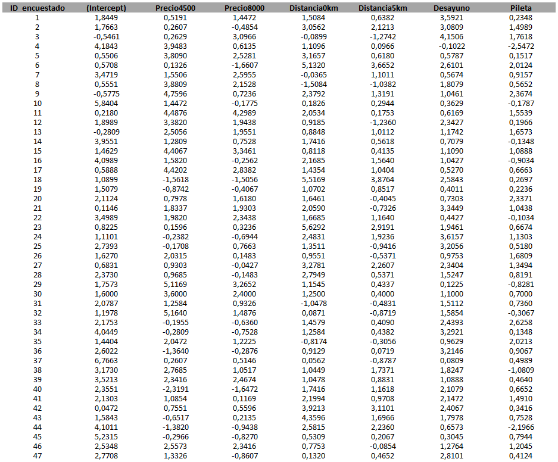

Adicionalmente, debajo se puede visualizar la cantidad de veces que cada coeficiente resultó ser significativo (1 si lo fue o 0 en caso contrario) tomando a los 47 encuestados. Lo que observamos es que el desayuno junto con la menor distancia son aspectos relevantes. Esto va a guardar mayor lógica con respecto al próximo apartado.

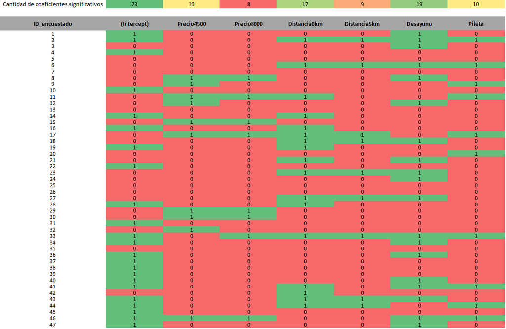

**2. Importancia relativa de cada atributo.**

Puede ampliarse este detalle a cada uno de los atributos de cada una de las regresiones de cada encuestado de manera análoga. Así, con toda esta información, podremos determinar la importancia relativa de cada atributo para cada encuestado. Esto nos va a mostrar cuanto se prefiere un atributo sobre los otros y ver el atributo más valorado por el consumidor.

La fórmula toma el rango (mejor menos peor resultado en utilidades) de los coeficientes de los diferentes niveles del atributo bajo análisis y lo divide en el total de los rangos de todos los atributos. De esta forma es que logramos captar la importancia relativa sobre los otros atributos.

A continuación, por una cuestión de espacio, veremos los resultados de los primeros 15 encuestados y la importancia relativa que le asignan a los atributos. Sin embargo, en el código mencionado con anterioridad se pueden obtener el resultado para la totalidad de encuestados. Observemos los resultados debajo:

```r
library(readxl)
library(tidyverse)
library(openxlsx)
library(ggplot2)

# Punto 2 y 3)####
# General ####
# To be able to plot the part-worth utilities, we will create a table with the relevant information
# We will keep the estimated coefficients (part-worth utilities)
coeffs <- as.vector(summary(linear_model)$coefficients[,1])
# To graph the part-worth utilities we must add the reference levels for each attribute (which have a zero value)
pw_ut <- c(coeffs[1], coeffs[2:3], 0, coeffs[4:5], 0, coeffs[6], 0, coeffs[7], 0)
# Define the levels
levels <- c("Intercept", "$4.500", "$8.000", "$25.000", "0km", "5km", "20km", "Incluye", "No incluye", "Incluye", "No incluye")
# Define the attributes
attributes <- c("Intercept", rep(c("Precio"), times = 3), rep(c("Distancia"), times = 3) ,
                rep(c("Desayuno"), times = 2), rep(c("Pileta"), times = 2))
# Create the part-worth utilities dataframe
pw_ut_df <- data.frame(Variable = attributes, Levels = levels, pw_ut)

# Import libraries to plot the part-worth utilities
library(ggplot2)
library(gridExtra)
# Get the subset of the dataframe for each attribue
data_precio <- subset(pw_ut_df, pw_ut_df$Variable == "Precio")
data_distancia <- subset(pw_ut_df, pw_ut_df$Variable == "Distancia")
data_desayuno <- subset(pw_ut_df, pw_ut_df$Variable == "Desayuno")
data_pileta <- subset(pw_ut_df, pw_ut_df$Variable == "Pileta")
# Define the plots for each attribute
gg <- ggplot(data = data_precio, aes(x = Levels, y = pw_ut, group = 1)) + geom_line() + geom_point() + ggtitle("Price in general") + ylab("Part-Worth Utilities")

# Question 2:
# Attributes importante calculation
# First, we must calculate the range of the part-worth utilities for each attribute and the total
data_precio_range <- max(data_precio$pw_ut) - min(data_precio$pw_ut)
data_distancia_range <- max(data_distancia$pw_ut) - min(data_distancia$pw_ut)
data_desayuno_range <- max(data_desayuno$pw_ut) - min(data_desayuno$pw_ut)
data_pileta_range <- max(data_pileta$pw_ut) - min(data_pileta$pw_ut)
total_range <- sum(data_precio_range + data_distancia_range + data_desayuno_range + data_pileta_range)
# Then, we can calculate the relative importance for each attribute
data_precio_importance <- data_precio_range/total_range
data_distancia_importance <- data_distancia_range/total_range
data_desayuno_importance <- data_desayuno_range/total_range
data_pileta_importance <- data_pileta_range/total_range
relative_importance <- data.frame(Attribute = c("Precio", "Distancia", "Desayuno", "Pileta"),
                                  Importance = round(c(data_precio_importance, data_distancia_importance, data_desayuno_importance, data_pileta_importance),4))
# Finally, we can visualize the relative importances
graf <- ggplot(relative_importance, aes(x = Attribute, y = Importance)) +
  geom_bar(stat = "identity") +
  ggtitle("Relative importance of attributes in general") +
  geom_text(position = position_stack(vjust = 0.8), size = 4,
            color="white",
            label= relative_importance$Importance)
# Ind_1 ####
# To be able to plot the part-worth utilities, we will create a table with the relevant information
# We will keep the estimated coefficients (part-worth utilities)
coeffs <- as.vector(summary(linear_model_ind1)$coefficients[,1])
# To graph the part-worth utilities we must add the reference levels for each attribute (which have a zero value)
pw_ut <- c(coeffs[1], coeffs[2:3], 0, coeffs[4:5], 0, coeffs[6], 0, coeffs[7], 0)
# Define the levels
levels <- c("Intercept", "$4.500", "$8.000", "$25.000", "0km", "5km", "20km", "Incluye", "No incluye", "Incluye", "No incluye")
# Define the attributes
attributes <- c("Intercept", rep(c("Precio"), times = 3), rep(c("Distancia"), times = 3) ,
                rep(c("Desayuno"), times = 2), rep(c("Pileta"), times = 2))
# Create the part-worth utilities dataframe
pw_ut_df <- data.frame(Variable = attributes, Levels = levels, pw_ut)

# Import libraries to plot the part-worth utilities
library(ggplot2)
library(gridExtra)
# Get the subset of the dataframe for each attribue
data_precio <- subset(pw_ut_df, pw_ut_df$Variable == "Precio")
data_distancia <- subset(pw_ut_df, pw_ut_df$Variable == "Distancia")
data_desayuno <- subset(pw_ut_df, pw_ut_df$Variable == "Desayuno")
data_pileta <- subset(pw_ut_df, pw_ut_df$Variable == "Pileta")
# Define the plots for each attribute
gg1 <- ggplot(data = data_precio, aes(x = Levels, y = pw_ut, group = 1)) + geom_line() + geom_point() + ggtitle("Price for person 1") + ylab("Part-Worth Utilities")

# Question 2:
# Attributes importante calculation
# First, we must calculate the range of the part-worth utilities for each attribute and the total
data_precio_range <- max(data_precio$pw_ut) - min(data_precio$pw_ut)
data_distancia_range <- max(data_distancia$pw_ut) - min(data_distancia$pw_ut)
data_desayuno_range <- max(data_desayuno$pw_ut) - min(data_desayuno$pw_ut)
data_pileta_range <- max(data_pileta$pw_ut) - min(data_pileta$pw_ut)
total_range <- sum(data_precio_range + data_distancia_range + data_desayuno_range + data_pileta_range)
# Then, we can calculate the relative importance for each attribute
data_precio_importance <- data_precio_range/total_range
data_distancia_importance <- data_distancia_range/total_range
data_desayuno_importance <- data_desayuno_range/total_range
data_pileta_importance <- data_pileta_range/total_range
relative_importance <- data.frame(Attribute = c("Precio", "Distancia", "Desayuno", "Pileta"),
                                  Importance = round(c(data_precio_importance, data_distancia_importance, data_desayuno_importance, data_pileta_importance),4))
# Finally, we can visualize the relative importances
graf1 <- ggplot(relative_importance, aes(x = Attribute, y = Importance)) +
  geom_bar(stat = "identity") +
  ggtitle("Relative importance of attributes for person 1") +
  geom_text(position = position_stack(vjust = 0.8), size = 4,
            color="white",
            label= relative_importance$Importance)
```

```r
# Ind_2 ####
# To be able to plot the part-worth utilities, we will create a table with the relevant information
# We will keep the estimated coefficients (part-worth utilities)
coeffs <- as.vector(summary(linear_model_ind2)$coefficients[,1])
# To graph the part-worth utilities we must add the reference levels for each attribute (which have a zero value)
pw_ut <- c(coeffs[1], coeffs[2:3], 0, coeffs[4:5], 0, coeffs[6], 0, coeffs[7], 0)
# Define the levels
levels <- c("Intercept", "$4.500", "$8.000", "$25.000", "0km", "5km", "20km", "Incluye", "No incluye", "Incluye", "No incluye")
# Define the attributes
attributes <- c("Intercept", rep(c("Precio"), times = 3), rep(c("Distancia"), times = 3) ,
                rep(c("Desayuno"), times = 2), rep(c("Pileta"), times = 2))
# Create the part-worth utilities dataframe
pw_ut_df <- data.frame(Variable = attributes, Levels = levels, pw_ut)

# Import libraries to plot the part-worth utilities
library(ggplot2)
library(gridExtra)
# Get the subset of the dataframe for each attribue
data_precio <- subset(pw_ut_df, pw_ut_df$Variable == "Precio")
data_distancia <- subset(pw_ut_df, pw_ut_df$Variable == "Distancia")
data_desayuno <- subset(pw_ut_df, pw_ut_df$Variable == "Desayuno")
data_pileta <- subset(pw_ut_df, pw_ut_df$Variable == "Pileta")
# Define the plots for each attribute
gg2 <- ggplot(data = data_precio, aes(x = Levels, y = pw_ut, group = 1)) + geom_line() + geom_point() + ggtitle("Price for person 2") + ylab("Part-Worth Utilities")

# Question 2:
# Attributes importante calculation
# First, we must calculate the range of the part-worth utilities for each attribute and the total
data_precio_range <- max(data_precio$pw_ut) - min(data_precio$pw_ut)
data_distancia_range <- max(data_distancia$pw_ut) - min(data_distancia$pw_ut)
data_desayuno_range <- max(data_desayuno$pw_ut) - min(data_desayuno$pw_ut)
data_pileta_range <- max(data_pileta$pw_ut) - min(data_pileta$pw_ut)
total_range <- sum(data_precio_range + data_distancia_range + data_desayuno_range + data_pileta_range)
# Then, we can calculate the relative importance for each attribute
data_precio_importance <- data_precio_range/total_range
data_distancia_importance <- data_distancia_range/total_range
data_desayuno_importance <- data_desayuno_range/total_range
data_pileta_importance <- data_pileta_range/total_range
relative_importance <- data.frame(Attribute = c("Precio", "Distancia", "Desayuno", "Pileta"),
                                  Importance = round(c(data_precio_importance, data_distancia_importance, data_desayuno_importance, data_pileta_importance),4))
# Finally, we can visualize the relative importances
graf2 <- ggplot(relative_importance, aes(x = Attribute, y = Importance)) +
  geom_bar(stat = "identity") +
  ggtitle("Relative importance of attributes for person 2") +
  geom_text(position = position_stack(vjust = 0.8), size = 4,
            color="white",
            label= relative_importance$Importance)



# Ind_3 ####
# To be able to plot the part-worth utilities, we will create a table with the relevant information
# We will keep the estimated coefficients (part-worth utilities)
coeffs <- as.vector(summary(linear_model_ind3)$coefficients[,1])
# To graph the part-worth utilities we must add the reference levels for each attribute (which have a zero value)
pw_ut <- c(coeffs[1], coeffs[2:3], 0, coeffs[4:5], 0, coeffs[6], 0, coeffs[7], 0)
# Define the levels
levels <- c("Intercept", "$4.500", "$8.000", "$25.000", "0km", "5km", "20km", "Incluye", "No incluye", "Incluye", "No incluye")
# Define the attributes
attributes <- c("Intercept", rep(c("Precio"), times = 3), rep(c("Distancia"), times = 3) ,
                rep(c("Desayuno"), times = 2), rep(c("Pileta"), times = 2))
# Create the part-worth utilities dataframe
pw_ut_df <- data.frame(Variable = attributes, Levels = levels, pw_ut)

# Import libraries to plot the part-worth utilities
library(ggplot2)
library(gridExtra)
# Get the subset of the dataframe for each attribue
data_precio <- subset(pw_ut_df, pw_ut_df$Variable == "Precio")
data_distancia <- subset(pw_ut_df, pw_ut_df$Variable == "Distancia")
data_desayuno <- subset(pw_ut_df, pw_ut_df$Variable == "Desayuno")
data_pileta <- subset(pw_ut_df, pw_ut_df$Variable == "Pileta")
# Define the plots for each attribute
gg3 <- ggplot(data = data_precio, aes(x = Levels, y = pw_ut, group = 1)) + geom_line() + geom_point() + ggtitle("Price for person 3") + ylab("Part-Worth Utilities")


# Question 2:
# Attributes importante calculation
# First, we must calculate the range of the part-worth utilities for each attribute and the total
data_precio_range <- max(data_precio$pw_ut) - min(data_precio$pw_ut)
data_distancia_range <- max(data_distancia$pw_ut) - min(data_distancia$pw_ut)
data_desayuno_range <- max(data_desayuno$pw_ut) - min(data_desayuno$pw_ut)
data_pileta_range <- max(data_pileta$pw_ut) - min(data_pileta$pw_ut)
total_range <- sum(data_precio_range + data_distancia_range + data_desayuno_range + data_pileta_range)
# Then, we can calculate the relative importance for each attribute
data_precio_importance <- data_precio_range/total_range
data_distancia_importance <- data_distancia_range/total_range
data_desayuno_importance <- data_desayuno_range/total_range
data_pileta_importance <- data_pileta_range/total_range
relative_importance <- data.frame(Attribute = c("Precio", "Distancia", "Desayuno", "Pileta"),
                                  Importance = round(c(data_precio_importance, data_distancia_importance, data_desayuno_importance, data_pileta_importance),4))
# Finally, we can visualize the relative importances
graf3 <- ggplot(relative_importance, aes(x = Attribute, y = Importance)) +
  geom_bar(stat = "identity") +
  ggtitle("Relative importance of attributes for person 3") +
  geom_text(position = position_stack(vjust = 0.8), size = 4,
            color="white",
            label= relative_importance$Importance)


# Ind_4 ####
# To be able to plot the part-worth utilities, we will create a table with the relevant information
# We will keep the estimated coefficients (part-worth utilities)
coeffs <- as.vector(summary(linear_model_ind4)$coefficients[,1])
# To graph the part-worth utilities we must add the reference levels for each attribute (which have a zero value)
pw_ut <- c(coeffs[1], coeffs[2:3], 0, coeffs[4:5], 0, coeffs[6], 0, coeffs[7], 0)
# Define the levels
levels <- c("Intercept", "$4.500", "$8.000", "$25.000", "0km", "5km", "20km", "Incluye", "No incluye", "Incluye", "No incluye")
# Define the attributes
attributes <- c("Intercept", rep(c("Precio"), times = 3), rep(c("Distancia"), times = 3) ,
                rep(c("Desayuno"), times = 2), rep(c("Pileta"), times = 2))
# Create the part-worth utilities dataframe
pw_ut_df <- data.frame(Variable = attributes, Levels = levels, pw_ut)
```

```r
# Import libraries to plot the part-worth utilities
library(ggplot2)
library(gridExtra)
# Get the subset of the dataframe for each attribue
data_precio <- subset(pw_ut_df, pw_ut_df$Variable == "Precio")
data_distancia <- subset(pw_ut_df, pw_ut_df$Variable == "Distancia")
data_desayuno <- subset(pw_ut_df, pw_ut_df$Variable == "Desayuno")
data_pileta <- subset(pw_ut_df, pw_ut_df$Variable == "Pileta")
# Define the plots for each attribute
gg4 <- ggplot(data = data_precio, aes(x = Levels, y = pw_ut, group = 1)) + geom_line() + geom_point() + ggtitle("Price for person 4") + ylab("Part-Worth Utilities")

# Question 2:
# Attributes importante calculation
# First, we must calculate the range of the part-worth utilities for each attribute and the total
data_precio_range <- max(data_precio$pw_ut) - min(data_precio$pw_ut)
data_distancia_range <- max(data_distancia$pw_ut) - min(data_distancia$pw_ut)
data_desayuno_range <- max(data_desayuno$pw_ut) - min(data_desayuno$pw_ut)
data_pileta_range <- max(data_pileta$pw_ut) - min(data_pileta$pw_ut)
total_range <- sum(data_precio_range + data_distancia_range + data_desayuno_range + data_pileta_range)
# Then, we can calculate the relative importance for each attribute
data_precio_importance <- data_precio_range/total_range
data_distancia_importance <- data_distancia_range/total_range
data_desayuno_importance <- data_desayuno_range/total_range
data_pileta_importance <- data_pileta_range/total_range
relative_importance <- data.frame(Attribute = c("Precio", "Distancia", "Desayuno", "Pileta"),
                                  Importance = round(c(data_precio_importance, data_distancia_importance, data_desayuno_importance, data_pileta_importance),4))
# Finally, we can visualize the relative importances
graf4 <- ggplot(relative_importance, aes(x = Attribute, y = Importance)) +
  geom_bar(stat = "identity") +
  ggtitle("Relative importance of attributes for person 4") +
  geom_text(position = position_stack(vjust = 0.8), size = 4,
            color="white",
            label= relative_importance$Importance)


# Ind_5 ####
# To be able to plot the part-worth utilities, we will create a table with the relevant information
# We will keep the estimated coefficients (part-worth utilities)
coeffs <- as.vector(summary(linear_model_ind5)$coefficients[,1])
# To graph the part-worth utilities we must add the reference levels for each attribute (which have a zero value)
pw_ut <- c(coeffs[1], coeffs[2:3], 0, coeffs[4:5], 0, coeffs[6], 0, coeffs[7], 0)
# Define the levels
levels <- c("Intercept", "$4.500", "$8.000", "$25.000", "0km", "5km", "20km", "Incluye", "No incluye", "Incluye", "No incluye")
# Define the attributes
attributes <- c("Intercept", rep(c("Precio"), times = 3), rep(c("Distancia"), times = 3) ,
                rep(c("Desayuno"), times = 2), rep(c("Pileta"), times = 2))
# Create the part-worth utilities dataframe
pw_ut_df <- data.frame(Variable = attributes, Levels = levels, pw_ut)

# Import libraries to plot the part-worth utilities
library(ggplot2)
library(gridExtra)
# Get the subset of the dataframe for each attribue
data_precio <- subset(pw_ut_df, pw_ut_df$Variable == "Precio")
data_distancia <- subset(pw_ut_df, pw_ut_df$Variable == "Distancia")
data_desayuno <- subset(pw_ut_df, pw_ut_df$Variable == "Desayuno")
data_pileta <- subset(pw_ut_df, pw_ut_df$Variable == "Pileta")
# Define the plots for each attribute
gg5 <- ggplot(data = data_precio, aes(x = Levels, y = pw_ut, group = 1)) + geom_line() + geom_point() + ggtitle("Price for person 5") + ylab("Part-Worth Utilities")

# Question 2:
# Attributes importante calculation
# First, we must calculate the range of the part-worth utilities for each attribute and the total
data_precio_range <- max(data_precio$pw_ut) - min(data_precio$pw_ut)
data_distancia_range <- max(data_distancia$pw_ut) - min(data_distancia$pw_ut)
data_desayuno_range <- max(data_desayuno$pw_ut) - min(data_desayuno$pw_ut)
data_pileta_range <- max(data_pileta$pw_ut) - min(data_pileta$pw_ut)
total_range <- sum(data_precio_range + data_distancia_range + data_desayuno_range + data_pileta_range)
# Then, we can calculate the relative importance for each attribute
data_precio_importance <- data_precio_range/total_range
data_distancia_importance <- data_distancia_range/total_range
data_desayuno_importance <- data_desayuno_range/total_range
data_pileta_importance <- data_pileta_range/total_range
relative_importance <- data.frame(Attribute = c("Precio", "Distancia", "Desayuno", "Pileta"),
                                  Importance = round(c(data_precio_importance, data_distancia_importance, data_desayuno_importance, data_pileta_importance),4))
# Finally, we can visualize the relative importances
graf5 <- ggplot(relative_importance, aes(x = Attribute, y = Importance)) +
  geom_bar(stat = "identity") +
  ggtitle("Relative importance of attributes for person 5") +
  geom_text(position = position_stack(vjust = 0.8), size = 4,
            color="white",
            label= relative_importance$Importance)



# Ind_6 ####
# To be able to plot the part-worth utilities, we will create a table with the relevant information
# We will keep the estimated coefficients (part-worth utilities)
coeffs <- as.vector(summary(linear_model_ind6)$coefficients[,1])
# To graph the part-worth utilities we must add the reference levels for each attribute (which have a zero value)
pw_ut <- c(coeffs[1], coeffs[2:3], 0, coeffs[4:5], 0, coeffs[6], 0, coeffs[7], 0)
# Define the levels
levels <- c("Intercept", "$4.500", "$8.000", "$25.000", "0km", "5km", "20km", "Incluye", "No incluye", "Incluye", "No incluye")
# Define the attributes
attributes <- c("Intercept", rep(c("Precio"), times = 3), rep(c("Distancia"), times = 3) ,
                rep(c("Desayuno"), times = 2), rep(c("Pileta"), times = 2))
# Create the part-worth utilities dataframe
pw_ut_df <- data.frame(Variable = attributes, Levels = levels, pw_ut)

# Import libraries to plot the part-worth utilities
library(ggplot2)
library(gridExtra)
# Get the subset of the dataframe for each attribue
data_precio <- subset(pw_ut_df, pw_ut_df$Variable == "Precio")
data_distancia <- subset(pw_ut_df, pw_ut_df$Variable == "Distancia")
data_desayuno <- subset(pw_ut_df, pw_ut_df$Variable == "Desayuno")
data_pileta <- subset(pw_ut_df, pw_ut_df$Variable == "Pileta")
# Define the plots for each attribute
gg6 <- ggplot(data = data_precio, aes(x = Levels, y = pw_ut, group = 1)) + geom_line() + geom_point() + ggtitle("Price for person 6") + ylab("Part-Worth Utilities")
```

```r
# Question 2:
# Attributes importante calculation
# First, we must calculate the range of the part-worth utilities for each attribute and the total
data_precio_range <- max(data_precio$pw_ut) - min(data_precio$pw_ut)
data_distancia_range <- max(data_distancia$pw_ut) - min(data_distancia$pw_ut)
data_desayuno_range <- max(data_desayuno$pw_ut) - min(data_desayuno$pw_ut)
data_pileta_range <- max(data_pileta$pw_ut) - min(data_pileta$pw_ut)
total_range <- sum(data_precio_range + data_distancia_range + data_desayuno_range + data_pileta_range)
# Then, we can calculate the relative importance for each attribute
data_precio_importance <- data_precio_range/total_range
data_distancia_importance <- data_distancia_range/total_range
data_desayuno_importance <- data_desayuno_range/total_range
data_pileta_importance <- data_pileta_range/total_range
relative_importance <- data.frame(Attribute = c("Precio", "Distancia", "Desayuno", "Pileta"),
                                  Importance = round(c(data_precio_importance, data_distancia_importance, data_desayuno_importance, data_pileta_importance),4))
# Finally, we can visualize the relative importances
graf6 <- ggplot(relative_importance, aes(x = Attribute, y = Importance)) +
  geom_bar(stat = "identity") +
  ggtitle("Relative importance of attributes for person 6") +
  geom_text(position = position_stack(vjust = 0.8), size = 4,
            color="white",
            label= relative_importance$Importance)



# Ind_7 ####
# To be able to plot the part-worth utilities, we will create a table with the relevant information
# We will keep the estimated coefficients (part-worth utilities)
coeffs <- as.vector(summary(linear_model_ind7)$coefficients[,1])
# To graph the part-worth utilities we must add the reference levels for each attribute (which have a zero value)
pw_ut <- c(coeffs[1], coeffs[2:3], 0, coeffs[4:5], 0, coeffs[6], 0, coeffs[7], 0)
# Define the levels
levels <- c("Intercept", "$4.500", "$8.000", "$25.000", "0km", "5km", "20km", "Incluye", "No incluye", "Incluye", "No incluye")
# Define the attributes
attributes <- c("Intercept", rep(c("Precio"), times = 3), rep(c("Distancia"), times = 3) ,
                rep(c("Desayuno"), times = 2), rep(c("Pileta"), times = 2))
# Create the part-worth utilities dataframe
pw_ut_df <- data.frame(Variable = attributes, Levels = levels, pw_ut)

# Import libraries to plot the part-worth utilities
library(ggplot2)
library(gridExtra)
# Get the subset of the dataframe for each attribue
data_precio <- subset(pw_ut_df, pw_ut_df$Variable == "Precio")
data_distancia <- subset(pw_ut_df, pw_ut_df$Variable == "Distancia")
data_desayuno <- subset(pw_ut_df, pw_ut_df$Variable == "Desayuno")
data_pileta <- subset(pw_ut_df, pw_ut_df$Variable == "Pileta")
# Define the plots for each attribute
gg7 <- ggplot(data = data_precio, aes(x = Levels, y = pw_ut, group = 1)) + geom_line() + geom_point() + ggtitle("Price for person 7") + ylab("Part-Worth Utilities")

# Question 2:
# Attributes importante calculation
# First, we must calculate the range of the part-worth utilities for each attribute and the total
data_precio_range <- max(data_precio$pw_ut) - min(data_precio$pw_ut)
data_distancia_range <- max(data_distancia$pw_ut) - min(data_distancia$pw_ut)
data_desayuno_range <- max(data_desayuno$pw_ut) - min(data_desayuno$pw_ut)
data_pileta_range <- max(data_pileta$pw_ut) - min(data_pileta$pw_ut)
total_range <- sum(data_precio_range + data_distancia_range + data_desayuno_range + data_pileta_range)
# Then, we can calculate the relative importance for each attribute
data_precio_importance <- data_precio_range/total_range
data_distancia_importance <- data_distancia_range/total_range
data_desayuno_importance <- data_desayuno_range/total_range
data_pileta_importance <- data_pileta_range/total_range
relative_importance <- data.frame(Attribute = c("Precio", "Distancia", "Desayuno", "Pileta"),
                                  Importance = round(c(data_precio_importance, data_distancia_importance, data_desayuno_importance, data_pileta_importance),4))
# Finally, we can visualize the relative importances
graf7 <- ggplot(relative_importance, aes(x = Attribute, y = Importance)) +
  geom_bar(stat = "identity") +
  ggtitle("Relative importance of attributes for person 7") +
  geom_text(position = position_stack(vjust = 0.8), size = 4,
            color="white",
            label= relative_importance$Importance)



# Ind_8 ####
# To be able to plot the part-worth utilities, we will create a table with the relevant information
# We will keep the estimated coefficients (part-worth utilities)
coeffs <- as.vector(summary(linear_model_ind8)$coefficients[,1])
# To graph the part-worth utilities we must add the reference levels for each attribute (which have a zero value)
pw_ut <- c(coeffs[1], coeffs[2:3], 0, coeffs[4:5], 0, coeffs[6], 0, coeffs[7], 0)
# Define the levels
levels <- c("Intercept", "$4.500", "$8.000", "$25.000", "0km", "5km", "20km", "Incluye", "No incluye", "Incluye", "No incluye")
# Define the attributes
attributes <- c("Intercept", rep(c("Precio"), times = 3), rep(c("Distancia"), times = 3) ,
                rep(c("Desayuno"), times = 2), rep(c("Pileta"), times = 2))
# Create the part-worth utilities dataframe
pw_ut_df <- data.frame(Variable = attributes, Levels = levels, pw_ut)

# Import libraries to plot the part-worth utilities
library(ggplot2)
library(gridExtra)
# Get the subset of the dataframe for each attribue
data_precio <- subset(pw_ut_df, pw_ut_df$Variable == "Precio")
data_distancia <- subset(pw_ut_df, pw_ut_df$Variable == "Distancia")
data_desayuno <- subset(pw_ut_df, pw_ut_df$Variable == "Desayuno")
data_pileta <- subset(pw_ut_df, pw_ut_df$Variable == "Pileta")
# Define the plots for each attribute
gg8 <- ggplot(data = data_precio, aes(x = Levels, y = pw_ut, group = 1)) + geom_line() + geom_point() + ggtitle("Price for person 8") + ylab("Part-Worth Utilities")


# Question 2:
# Attributes importante calculation
# First, we must calculate the range of the part-worth utilities for each attribute and the total
data_precio_range <- max(data_precio$pw_ut) - min(data_precio$pw_ut)
data_distancia_range <- max(data_distancia$pw_ut) - min(data_distancia$pw_ut)
data_desayuno_range <- max(data_desayuno$pw_ut) - min(data_desayuno$pw_ut)
data_pileta_range <- max(data_pileta$pw_ut) - min(data_pileta$pw_ut)
total_range <- sum(data_precio_range + data_distancia_range + data_desayuno_range + data_pileta_range)
# Then, we can calculate the relative importance for each attribute
data_precio_importance <- data_precio_range/total_range
data_distancia_importance <- data_distancia_range/total_range
data_desayuno_importance <- data_desayuno_range/total_range
data_pileta_importance <- data_pileta_range/total_range
relative_importance <- data.frame(Attribute = c("Precio", "Distancia", "Desayuno", "Pileta"),
                                  Importance = round(c(data_precio_importance, data_distancia_importance, data_desayuno_importance, data_pileta_importance),4))
# Finally, we can visualize the relative importances
graf8 <- ggplot(relative_importance, aes(x = Attribute, y = Importance)) +
  geom_bar(stat = "identity") +
  ggtitle("Relative importance of attributes for person 8") +
  geom_text(position = position_stack(vjust = 0.8), size = 4,
            color="white",
            label= relative_importance$Importance)
```

```r
# Ind_9 ####
# To be able to plot the part-worth utilities, we will create a table with the relevant information
# We will keep the estimated coefficients (part-worth utilities)
coeffs <- as.vector(summary(linear_model_ind9)$coefficients[,1])
# To graph the part-worth utilities we must add the reference levels for each attribute (which have a zero value)
pw_ut <- c(coeffs[1], coeffs[2:3], 0, coeffs[4:5], 0, coeffs[6], 0, coeffs[7], 0)
# Define the levels
levels <- c("Intercept", "$4.500", "$8.000", "$25.000", "0km", "5km", "20km", "Incluye", "No incluye", "Incluye", "No incluye")
# Define the attributes
attributes <- c("Intercept", rep(c("Precio"), times = 3), rep(c("Distancia"), times = 3) ,
                rep(c("Desayuno"), times = 2), rep(c("Pileta"), times = 2))
# Create the part-worth utilities dataframe
pw_ut_df <- data.frame(Variable = attributes, Levels = levels, pw_ut)

# Import libraries to plot the part-worth utilities
library(ggplot2)
library(gridExtra)
# Get the subset of the dataframe for each attribue
data_precio <- subset(pw_ut_df, pw_ut_df$Variable == "Precio")
data_distancia <- subset(pw_ut_df, pw_ut_df$Variable == "Distancia")
data_desayuno <- subset(pw_ut_df, pw_ut_df$Variable == "Desayuno")
data_pileta <- subset(pw_ut_df, pw_ut_df$Variable == "Pileta")
# Define the plots for each attribute
gg9 <- ggplot(data = data_precio, aes(x = Levels, y = pw_ut, group = 1)) + geom_line() + geom_point() + ggtitle("Price for person 9") + ylab("Part-Worth Utilities")


# Question 2:
# Attributes importante calculation
# First, we must calculate the range of the part-worth utilities for each attribute and the total
data_precio_range <- max(data_precio$pw_ut) - min(data_precio$pw_ut)
data_distancia_range <- max(data_distancia$pw_ut) - min(data_distancia$pw_ut)
data_desayuno_range <- max(data_desayuno$pw_ut) - min(data_desayuno$pw_ut)
data_pileta_range <- max(data_pileta$pw_ut) - min(data_pileta$pw_ut)
total_range <- sum(data_precio_range + data_distancia_range + data_desayuno_range + data_pileta_range)
# Then, we can calculate the relative importance for each attribute
data_precio_importance <- data_precio_range/total_range
data_distancia_importance <- data_distancia_range/total_range
data_desayuno_importance <- data_desayuno_range/total_range
data_pileta_importance <- data_pileta_range/total_range
relative_importance <- data.frame(Attribute = c("Precio", "Distancia", "Desayuno", "Pileta"),
                                  Importance = round(c(data_precio_importance, data_distancia_importance, data_desayuno_importance, data_pileta_importance),4))
# Finally, we can visualize the relative importances
graf9 <- ggplot(relative_importance, aes(x = Attribute, y = Importance)) +
  geom_bar(stat = "identity") +
  ggtitle("Relative importance of attributes for person 9") +
  geom_text(position = position_stack(vjust = 0.8), size = 4,
            color="white",
            label= relative_importance$Importance)



# Ind_10 ####
# To be able to plot the part-worth utilities, we will create a table with the relevant information
# We will keep the estimated coefficients (part-worth utilities)
coeffs <- as.vector(summary(linear_model_ind10)$coefficients[,1])
# To graph the part-worth utilities we must add the reference levels for each attribute (which have a zero value)
pw_ut <- c(coeffs[1], coeffs[2:3], 0, coeffs[4:5], 0, coeffs[6], 0, coeffs[7], 0)
# Define the levels
levels <- c("Intercept", "$4.500", "$8.000", "$25.000", "0km", "5km", "20km", "Incluye", "No incluye", "Incluye", "No incluye")
# Define the attributes
attributes <- c("Intercept", rep(c("Precio"), times = 3), rep(c("Distancia"), times = 3) ,
                rep(c("Desayuno"), times = 2), rep(c("Pileta"), times = 2))
# Create the part-worth utilities dataframe
pw_ut_df <- data.frame(Variable = attributes, Levels = levels, pw_ut)

# Import libraries to plot the part-worth utilities
library(ggplot2)
library(gridExtra)
# Get the subset of the dataframe for each attribue
data_precio <- subset(pw_ut_df, pw_ut_df$Variable == "Precio")
data_distancia <- subset(pw_ut_df, pw_ut_df$Variable == "Distancia")
data_desayuno <- subset(pw_ut_df, pw_ut_df$Variable == "Desayuno")
data_pileta <- subset(pw_ut_df, pw_ut_df$Variable == "Pileta")
# Define the plots for each attribute
gg10 <- ggplot(data = data_precio, aes(x = Levels, y = pw_ut, group = 1)) + geom_line() + geom_point() + ggtitle("Price for person 10") + ylab("Part-Worth Utilities")


# Question 2:
# Attributes importante calculation
# First, we must calculate the range of the part-worth utilities for each attribute and the total
data_precio_range <- max(data_precio$pw_ut) - min(data_precio$pw_ut)
data_distancia_range <- max(data_distancia$pw_ut) - min(data_distancia$pw_ut)
data_desayuno_range <- max(data_desayuno$pw_ut) - min(data_desayuno$pw_ut)
data_pileta_range <- max(data_pileta$pw_ut) - min(data_pileta$pw_ut)
total_range <- sum(data_precio_range + data_distancia_range + data_desayuno_range + data_pileta_range)
# Then, we can calculate the relative importance for each attribute
data_precio_importance <- data_precio_range/total_range
data_distancia_importance <- data_distancia_range/total_range
data_desayuno_importance <- data_desayuno_range/total_range
data_pileta_importance <- data_pileta_range/total_range
relative_importance <- data.frame(Attribute = c("Precio", "Distancia", "Desayuno", "Pileta"),
                                  Importance = round(c(data_precio_importance, data_distancia_importance, data_desayuno_importance, data_pileta_importance),4))
# Finally, we can visualize the relative importances
graf10 <- ggplot(relative_importance, aes(x = Attribute, y = Importance)) +
  geom_bar(stat = "identity") +
  ggtitle("Relative importance of attributes for person 10") +
  geom_text(position = position_stack(vjust = 0.8), size = 4,
            color="white",
            label= relative_importance$Importance)



# Ind_11 ####
# To be able to plot the part-worth utilities, we will create a table with the relevant information
# We will keep the estimated coefficients (part-worth utilities)
coeffs <- as.vector(summary(linear_model_ind11)$coefficients[,1])
# To graph the part-worth utilities we must add the reference levels for each attribute (which have a zero value)
pw_ut <- c(coeffs[1], coeffs[2:3], 0, coeffs[4:5], 0, coeffs[6], 0, coeffs[7], 0)
# Define the levels
levels <- c("Intercept", "$4.500", "$8.000", "$25.000", "0km", "5km", "20km", "Incluye", "No incluye", "Incluye", "No incluye")
# Define the attributes
attributes <- c("Intercept", rep(c("Precio"), times = 3), rep(c("Distancia"), times = 3) ,
                rep(c("Desayuno"), times = 2), rep(c("Pileta"), times = 2))
# Create the part-worth utilities dataframe
pw_ut_df <- data.frame(Variable = attributes, Levels = levels, pw_ut)
```

```r
# Import libraries to plot the part-worth utilities
library(ggplot2)
library(gridExtra)
# Get the subset of the dataframe for each attribue
data_precio <- subset(pw_ut_df, pw_ut_df$Variable == "Precio")
data_distancia <- subset(pw_ut_df, pw_ut_df$Variable == "Distancia")
data_desayuno <- subset(pw_ut_df, pw_ut_df$Variable == "Desayuno")
data_pileta <- subset(pw_ut_df, pw_ut_df$Variable == "Pileta")
# Define the plots for each attribute
gg11 <- ggplot(data = data_precio, aes(x = Levels, y = pw_ut, group = 1)) + geom_line() + geom_point() + ggtitle("Price for person 11") + ylab("Part-Worth Utilities")


# Question 2:
# Attributes importante calculation
# First, we must calculate the range of the part-worth utilities for each attribute and the total
data_precio_range <- max(data_precio$pw_ut) - min(data_precio$pw_ut)
data_distancia_range <- max(data_distancia$pw_ut) - min(data_distancia$pw_ut)
data_desayuno_range <- max(data_desayuno$pw_ut) - min(data_desayuno$pw_ut)
data_pileta_range <- max(data_pileta$pw_ut) - min(data_pileta$pw_ut)
total_range <- sum(data_precio_range + data_distancia_range + data_desayuno_range + data_pileta_range)
# Then, we can calculate the relative importance for each attribute
data_precio_importance <- data_precio_range/total_range
data_distancia_importance <- data_distancia_range/total_range
data_desayuno_importance <- data_desayuno_range/total_range
data_pileta_importance <- data_pileta_range/total_range
relative_importance <- data.frame(Attribute = c("Precio", "Distancia", "Desayuno", "Pileta"),
                                  Importance = round(c(data_precio_importance, data_distancia_importance, data_desayuno_importance, data_pileta_importance),4))
# Finally, we can visualize the relative importances
graf11 <- ggplot(relative_importance, aes(x = Attribute, y = Importance)) +
  geom_bar(stat = "identity") +
  ggtitle("Relative importance of attributes for person 11") +
  geom_text(position = position_stack(vjust = 0.8), size = 4,
            color="white",
            label= relative_importance$Importance)



# Ind_12 ####
# To be able to plot the part-worth utilities, we will create a table with the relevant information
# We will keep the estimated coefficients (part-worth utilities)
coeffs <- as.vector(summary(linear_model_ind12)$coefficients[,1])
# To graph the part-worth utilities we must add the reference levels for each attribute (which have a zero value)
pw_ut <- c(coeffs[1], coeffs[2:3], 0, coeffs[4:5], 0, coeffs[6], 0, coeffs[7], 0)
# Define the levels
levels <- c("Intercept", "$4.500", "$8.000", "$25.000", "0km", "5km", "20km", "Incluye", "No incluye", "Incluye", "No incluye")
# Define the attributes
attributes <- c("Intercept", rep(c("Precio"), times = 3), rep(c("Distancia"), times = 3) ,
                rep(c("Desayuno"), times = 2), rep(c("Pileta"), times = 2))
# Create the part-worth utilities dataframe
pw_ut_df <- data.frame(Variable = attributes, Levels = levels, pw_ut)

# Import libraries to plot the part-worth utilities
library(ggplot2)
library(gridExtra)
# Get the subset of the dataframe for each attribue
data_precio <- subset(pw_ut_df, pw_ut_df$Variable == "Precio")
data_distancia <- subset(pw_ut_df, pw_ut_df$Variable == "Distancia")
data_desayuno <- subset(pw_ut_df, pw_ut_df$Variable == "Desayuno")
data_pileta <- subset(pw_ut_df, pw_ut_df$Variable == "Pileta")
# Define the plots for each attribute
gg12 <- ggplot(data = data_precio, aes(x = Levels, y = pw_ut, group = 1)) + geom_line() + geom_point() + ggtitle("Price for person 12") + ylab("Part-Worth Utilities")


# Question 2:
# Attributes importante calculation
# First, we must calculate the range of the part-worth utilities for each attribute and the total
data_precio_range <- max(data_precio$pw_ut) - min(data_precio$pw_ut)
data_distancia_range <- max(data_distancia$pw_ut) - min(data_distancia$pw_ut)
data_desayuno_range <- max(data_desayuno$pw_ut) - min(data_desayuno$pw_ut)
data_pileta_range <- max(data_pileta$pw_ut) - min(data_pileta$pw_ut)
total_range <- sum(data_precio_range + data_distancia_range + data_desayuno_range + data_pileta_range)
# Then, we can calculate the relative importance for each attribute
data_precio_importance <- data_precio_range/total_range
data_distancia_importance <- data_distancia_range/total_range
data_desayuno_importance <- data_desayuno_range/total_range
data_pileta_importance <- data_pileta_range/total_range
relative_importance <- data.frame(Attribute = c("Precio", "Distancia", "Desayuno", "Pileta"),
                                  Importance = round(c(data_precio_importance, data_distancia_importance, data_desayuno_importance, data_pileta_importance),4))
# Finally, we can visualize the relative importances
graf12 <- ggplot(relative_importance, aes(x = Attribute, y = Importance)) +
  geom_bar(stat = "identity") +
  ggtitle("Relative importance of attributes for person 12") +
  geom_text(position = position_stack(vjust = 0.8), size = 4,
            color="white",
            label= relative_importance$Importance)



# Ind_13 ####
# To be able to plot the part-worth utilities, we will create a table with the relevant information
# We will keep the estimated coefficients (part-worth utilities)
coeffs <- as.vector(summary(linear_model_ind13)$coefficients[,1])
# To graph the part-worth utilities we must add the reference levels for each attribute (which have a zero value)
pw_ut <- c(coeffs[1], coeffs[2:3], 0, coeffs[4:5], 0, coeffs[6], 0, coeffs[7], 0)
# Define the levels
levels <- c("Intercept", "$4.500", "$8.000", "$25.000", "0km", "5km", "20km", "Incluye", "No incluye", "Incluye", "No incluye")
# Define the attributes
attributes <- c("Intercept", rep(c("Precio"), times = 3), rep(c("Distancia"), times = 3) ,
                rep(c("Desayuno"), times = 2), rep(c("Pileta"), times = 2))
# Create the part-worth utilities dataframe
pw_ut_df <- data.frame(Variable = attributes, Levels = levels, pw_ut)

# Import libraries to plot the part-worth utilities
library(ggplot2)
library(gridExtra)
# Get the subset of the dataframe for each attribue
data_precio <- subset(pw_ut_df, pw_ut_df$Variable == "Precio")
data_distancia <- subset(pw_ut_df, pw_ut_df$Variable == "Distancia")
data_desayuno <- subset(pw_ut_df, pw_ut_df$Variable == "Desayuno")
data_pileta <- subset(pw_ut_df, pw_ut_df$Variable == "Pileta")
# Define the plots for each attribute
gg13 <- ggplot(data = data_precio, aes(x = Levels, y = pw_ut, group = 1)) + geom_line() + geom_point() + ggtitle("Price for person 13") + ylab("Part-Worth Utilities")
```

```r
# Question 2:
# Attributes importante calculation
# First, we must calculate the range of the part-worth utilities for each attribute and the total
data_precio_range <- max(data_precio$pw_ut) - min(data_precio$pw_ut)
data_distancia_range <- max(data_distancia$pw_ut) - min(data_distancia$pw_ut)
data_desayuno_range <- max(data_desayuno$pw_ut) - min(data_desayuno$pw_ut)
data_pileta_range <- max(data_pileta$pw_ut) - min(data_pileta$pw_ut)
total_range <- sum(data_precio_range + data_distancia_range + data_desayuno_range + data_pileta_range)
# Then, we can calculate the relative importance for each attribute
data_precio_importance <- data_precio_range/total_range
data_distancia_importance <- data_distancia_range/total_range
data_desayuno_importance <- data_desayuno_range/total_range
data_pileta_importance <- data_pileta_range/total_range
relative_importance <- data.frame(Attribute = c("Precio", "Distancia", "Desayuno", "Pileta"),
                                  Importance = round(c(data_precio_importance, data_distancia_importance, data_desayuno_importance, data_pileta_importance),4))
# Finally, we can visualize the relative importances
graf13 <- ggplot(relative_importance, aes(x = Attribute, y = Importance)) +
  geom_bar(stat = "identity") +
  ggtitle("Relative importance of attributes for person 13") +
  geom_text(position = position_stack(vjust = 0.8), size = 4,
            color="white",
            label= relative_importance$Importance)


# Ind_14 ####
# To be able to plot the part-worth utilities, we will create a table with the relevant information
# We will keep the estimated coefficients (part-worth utilities)
coeffs <- as.vector(summary(linear_model_ind14)$coefficients[,1])
# To graph the part-worth utilities we must add the reference levels for each attribute (which have a zero value)
pw_ut <- c(coeffs[1], coeffs[2:3], 0, coeffs[4:5], 0, coeffs[6], 0, coeffs[7], 0)
# Define the levels
levels <- c("Intercept", "$4.500", "$8.000", "$25.000", "0km", "5km", "20km", "Incluye", "No incluye", "Incluye", "No incluye")
# Define the attributes
attributes <- c("Intercept", rep(c("Precio"), times = 3), rep(c("Distancia"), times = 3) ,
                rep(c("Desayuno"), times = 2), rep(c("Pileta"), times = 2))
# Create the part-worth utilities dataframe
pw_ut_df <- data.frame(Variable = attributes, Levels = levels, pw_ut)

# Import libraries to plot the part-worth utilities
library(ggplot2)
library(gridExtra)
# Get the subset of the dataframe for each attribue
data_precio <- subset(pw_ut_df, pw_ut_df$Variable == "Precio")
data_distancia <- subset(pw_ut_df, pw_ut_df$Variable == "Distancia")
data_desayuno <- subset(pw_ut_df, pw_ut_df$Variable == "Desayuno")
data_pileta <- subset(pw_ut_df, pw_ut_df$Variable == "Pileta")
# Define the plots for each attribute
gg14 <- ggplot(data = data_precio, aes(x = Levels, y = pw_ut, group = 1)) + geom_line() + geom_point() + ggtitle("Price for person 14") + ylab("Part-Worth Utilities")


# Question 2:
# Attributes importante calculation
# First, we must calculate the range of the part-worth utilities for each attribute and the total
data_precio_range <- max(data_precio$pw_ut) - min(data_precio$pw_ut)
data_distancia_range <- max(data_distancia$pw_ut) - min(data_distancia$pw_ut)
data_desayuno_range <- max(data_desayuno$pw_ut) - min(data_desayuno$pw_ut)
data_pileta_range <- max(data_pileta$pw_ut) - min(data_pileta$pw_ut)
total_range <- sum(data_precio_range + data_distancia_range + data_desayuno_range + data_pileta_range)
# Then, we can calculate the relative importance for each attribute
data_precio_importance <- data_precio_range/total_range
data_distancia_importance <- data_distancia_range/total_range
data_desayuno_importance <- data_desayuno_range/total_range
data_pileta_importance <- data_pileta_range/total_range
relative_importance <- data.frame(Attribute = c("Precio", "Distancia", "Desayuno", "Pileta"),
                                  Importance = round(c(data_precio_importance, data_distancia_importance, data_desayuno_importance, data_pileta_importance),4))
# Finally, we can visualize the relative importances
graf14 <- ggplot(relative_importance, aes(x = Attribute, y = Importance)) +
  geom_bar(stat = "identity") +
  ggtitle("Relative importance of attributes for person 14") +
  geom_text(position = position_stack(vjust = 0.8), size = 4,
            color="white",
            label= relative_importance$Importance)


# Ind_15 ####
# To be able to plot the part-worth utilities, we will create a table with the relevant information
# We will keep the estimated coefficients (part-worth utilities)
coeffs <- as.vector(summary(linear_model_ind15)$coefficients[,1])
# To graph the part-worth utilities we must add the reference levels for each attribute (which have a zero value)
pw_ut <- c(coeffs[1], coeffs[2:3], 0, coeffs[4:5], 0, coeffs[6], 0, coeffs[7], 0)
# Define the levels
levels <- c("Intercept", "$4.500", "$8.000", "$25.000", "0km", "5km", "20km", "Incluye", "No incluye", "Incluye", "No incluye")
# Define the attributes
attributes <- c("Intercept", rep(c("Precio"), times = 3), rep(c("Distancia"), times = 3) ,
                rep(c("Desayuno"), times = 2), rep(c("Pileta"), times = 2))
# Create the part-worth utilities dataframe
pw_ut_df <- data.frame(Variable = attributes, Levels = levels, pw_ut)

# Import libraries to plot the part-worth utilities
library(ggplot2)
library(gridExtra)
# Get the subset of the dataframe for each attribue
data_precio <- subset(pw_ut_df, pw_ut_df$Variable == "Precio")
data_distancia <- subset(pw_ut_df, pw_ut_df$Variable == "Distancia")
data_desayuno <- subset(pw_ut_df, pw_ut_df$Variable == "Desayuno")
data_pileta <- subset(pw_ut_df, pw_ut_df$Variable == "Pileta")
# Define the plots for each attribute
gg15 <- ggplot(data = data_precio, aes(x = Levels, y = pw_ut, group = 1)) + geom_line() + geom_point() + ggtitle("Price for person 15") + ylab("Part-Worth Utilities")


# Question 2:
# Attributes importante calculation
# First, we must calculate the range of the part-worth utilities for each attribute and the total
data_precio_range <- max(data_precio$pw_ut) - min(data_precio$pw_ut)
data_distancia_range <- max(data_distancia$pw_ut) - min(data_distancia$pw_ut)
data_desayuno_range <- max(data_desayuno$pw_ut) - min(data_desayuno$pw_ut)
data_pileta_range <- max(data_pileta$pw_ut) - min(data_pileta$pw_ut)
total_range <- sum(data_precio_range + data_distancia_range + data_desayuno_range + data_pileta_range)
# Then, we can calculate the relative importance for each attribute
data_precio_importance <- data_precio_range/total_range
data_distancia_importance <- data_distancia_range/total_range
data_desayuno_importance <- data_desayuno_range/total_range
data_pileta_importance <- data_pileta_range/total_range
relative_importance <- data.frame(Attribute = c("Precio", "Distancia", "Desayuno", "Pileta"),
                                  Importance = round(c(data_precio_importance, data_distancia_importance, data_desayuno_importance, data_pileta_importance),4))
# Finally, we can visualize the relative importances
graf15 <- ggplot(relative_importance, aes(x = Attribute, y = Importance)) +
  geom_bar(stat = "identity") +
  ggtitle("Relative importance of attributes for person 15") +
  geom_text(position = position_stack(vjust = 0.8), size = 4,
            color="white",
            label= relative_importance$Importance)
```

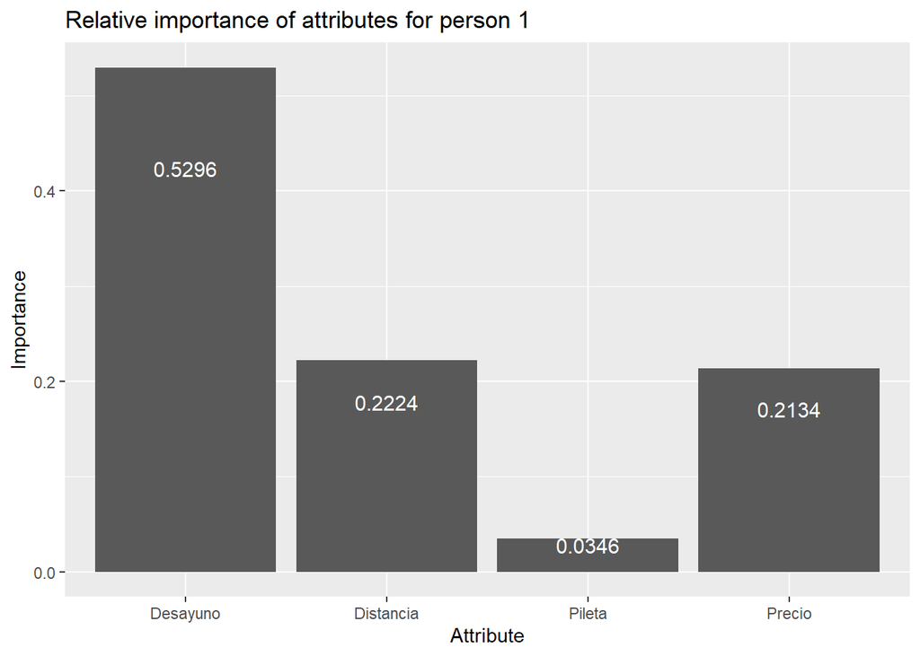

```r
# Plot them together
graf1
```

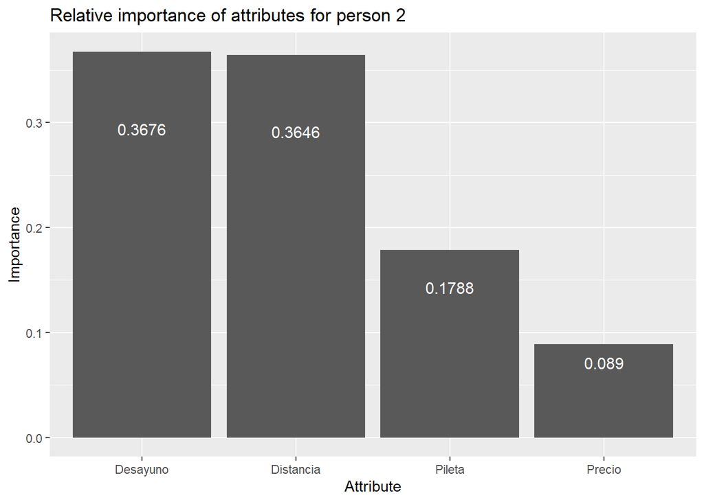

```r
graf2
```

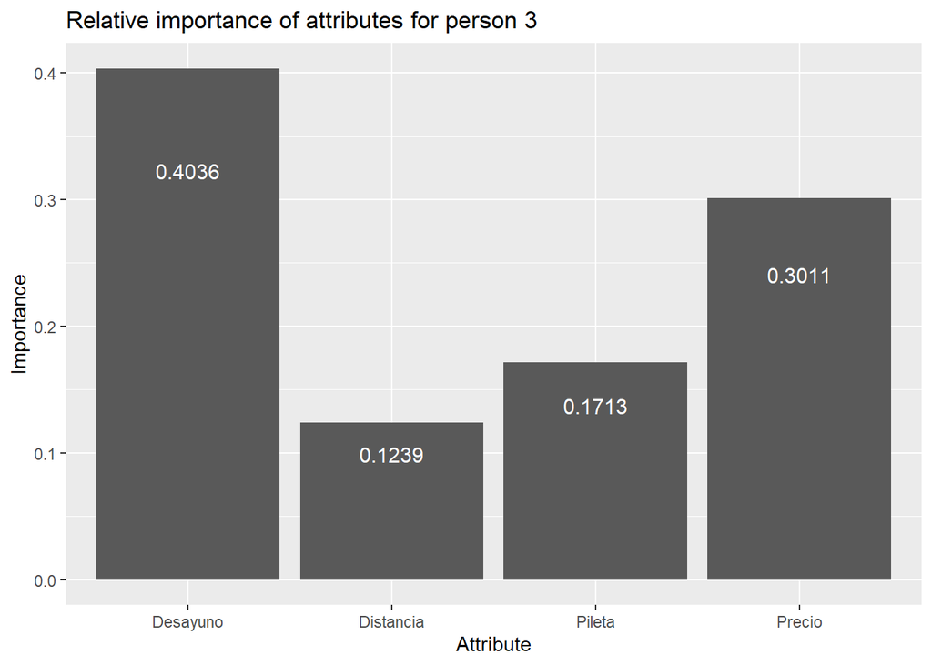

```r
graf3
```

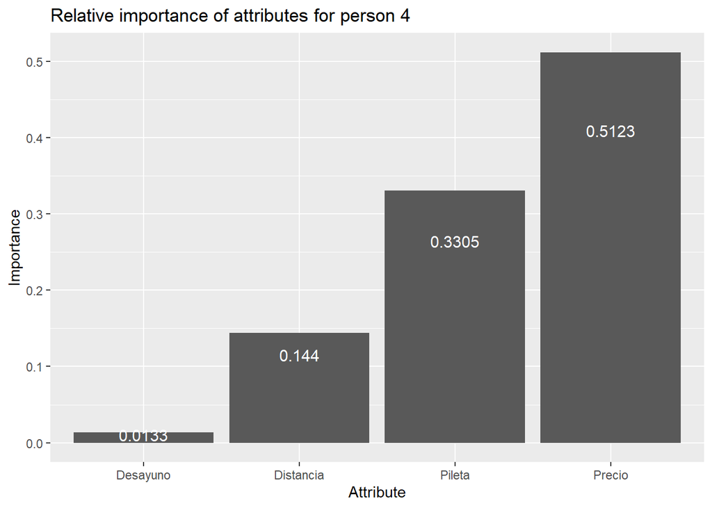

```r
graf4
```

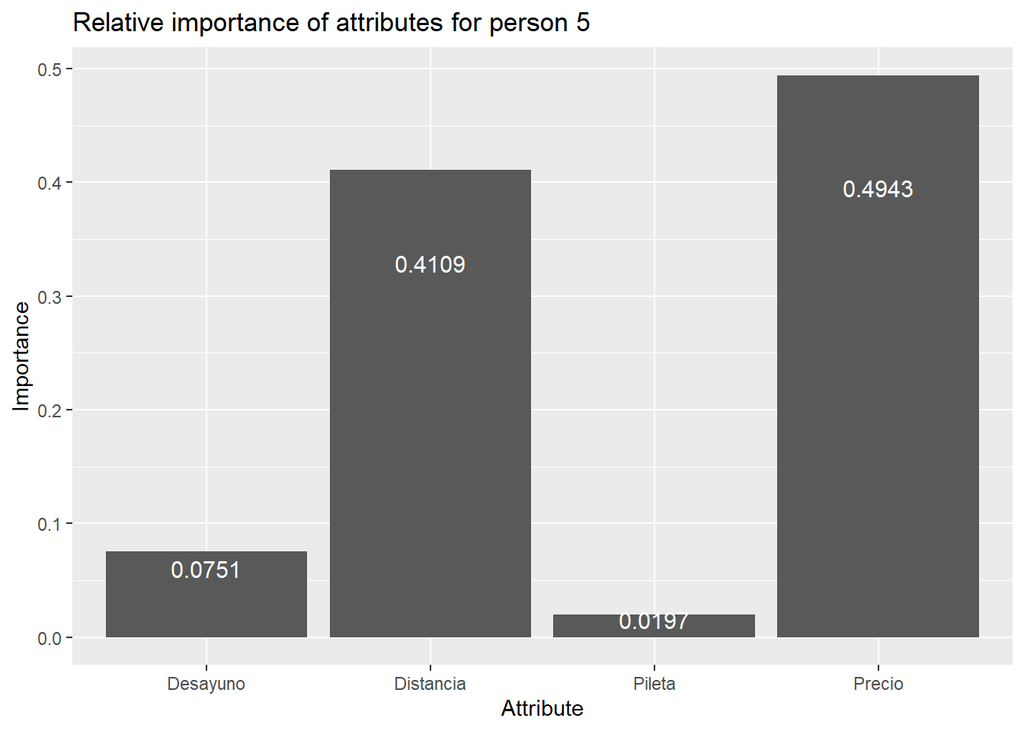

```r
graf5
```

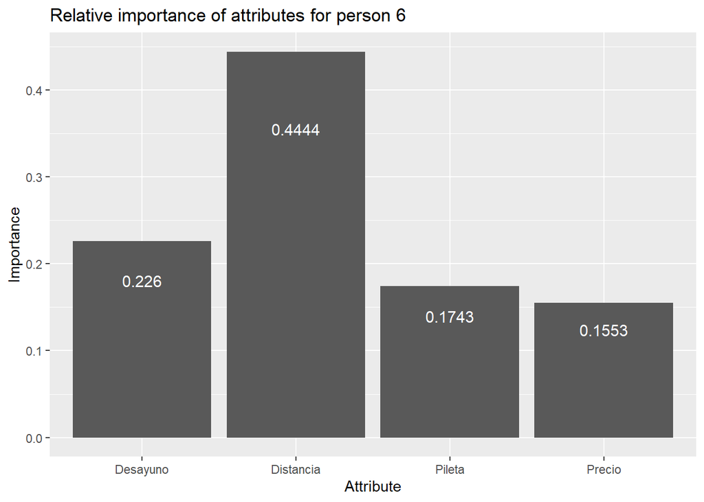

```r
graf6
```

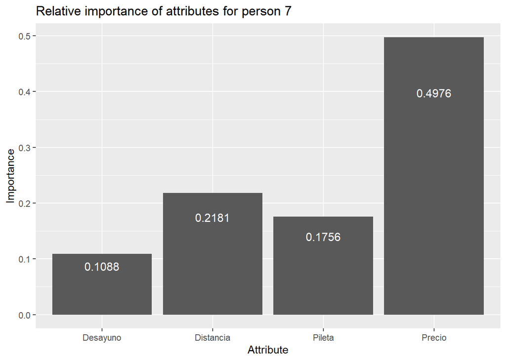

```r
graf7
```

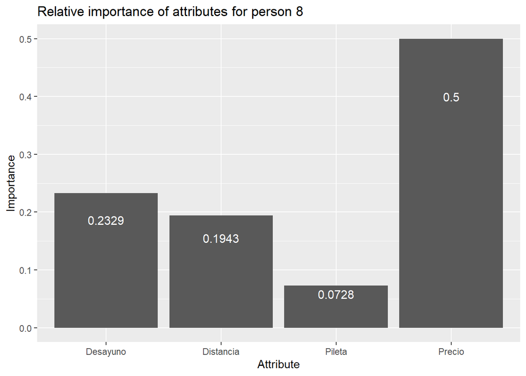

```r
graf8
```

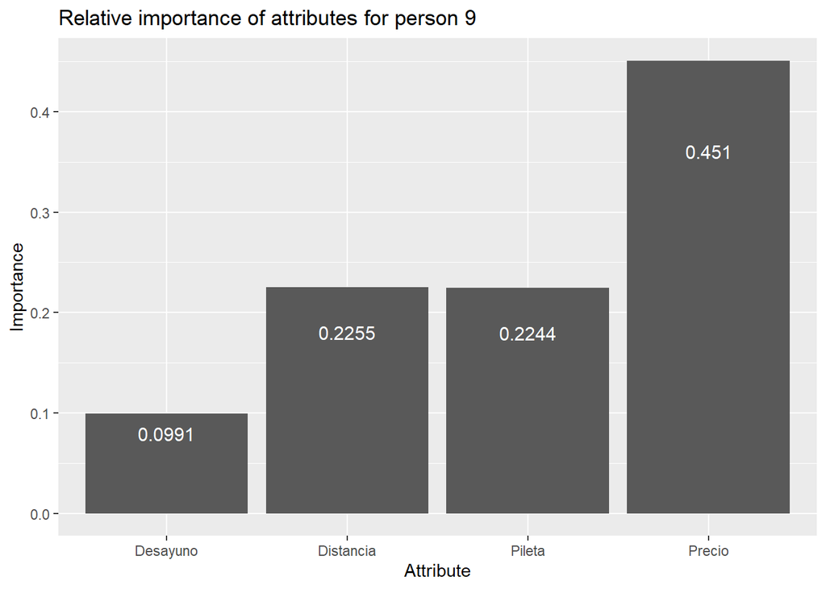

```r
graf9
```

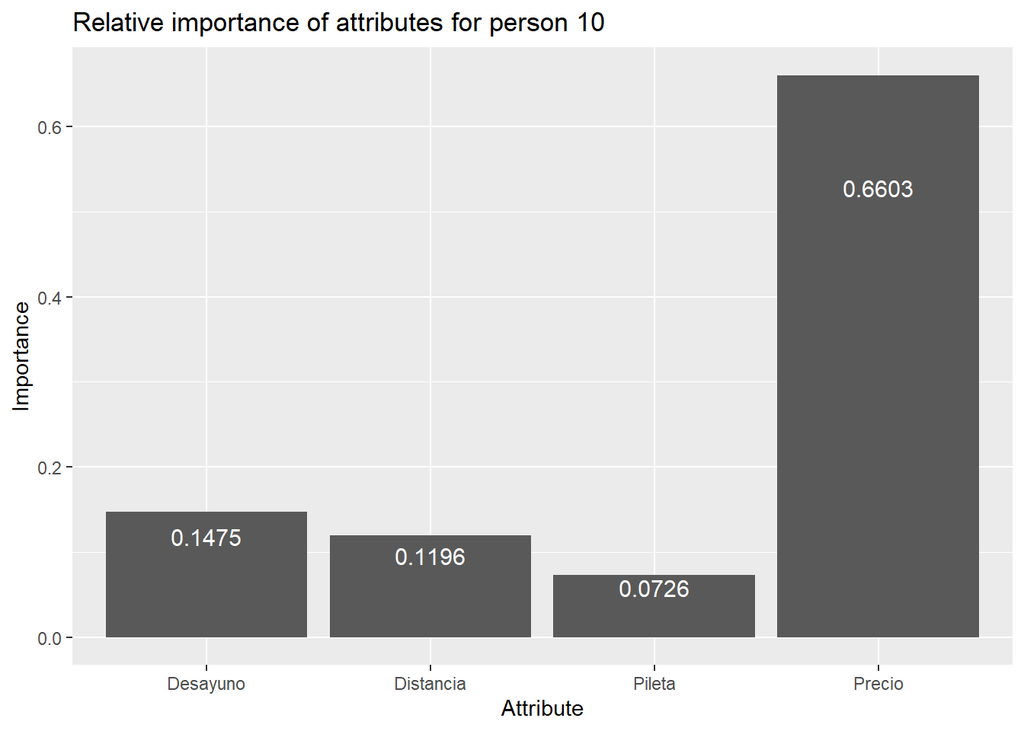

```r
graf10
```

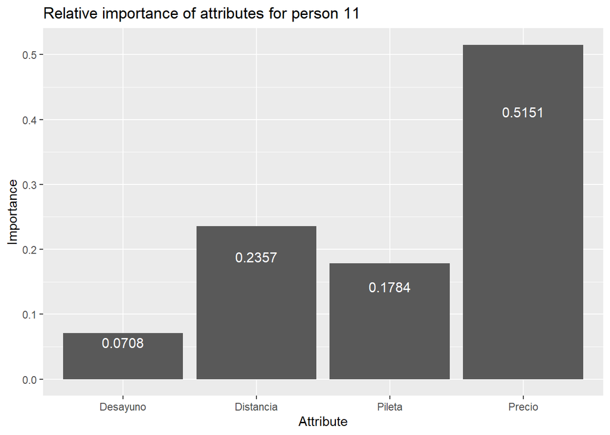

```r
graf11
```

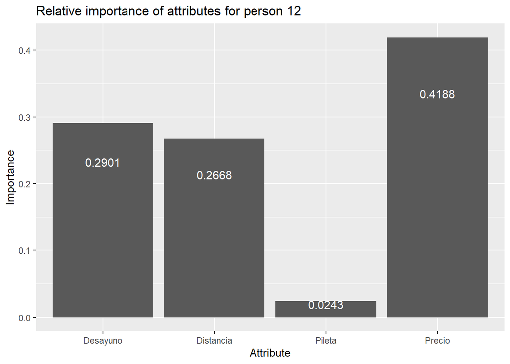

```r
graf12
```

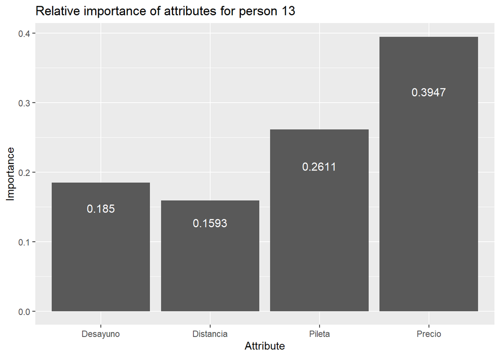

```r
graf13
```

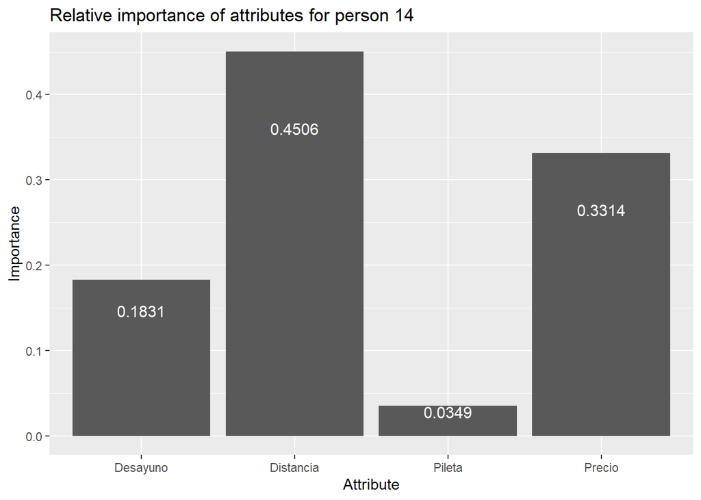

```r
graf14
```

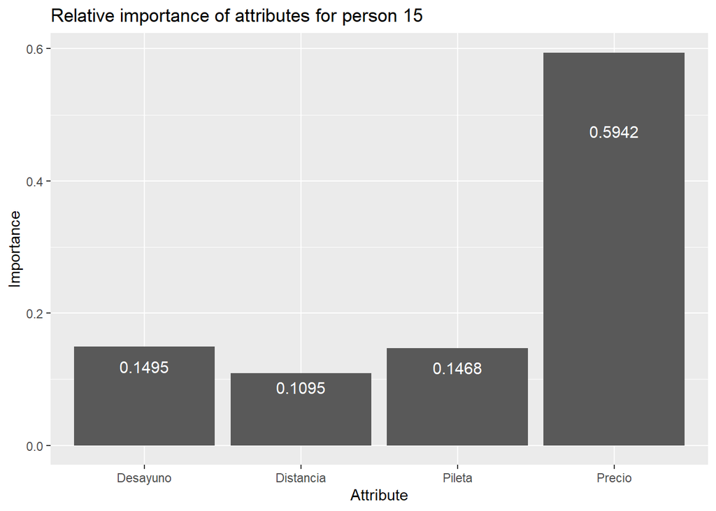

```r
graf15
```

Gráficamente podemos apreciar que cada consumidor le da una importancia relativa diferente a cada uno de los atributos. Esto es por la diversidad de gustos y preferencias.

A nivel general, con los 47 encuestados, podemos analizar esta misma información y poder ver la jerarquización de atributos a nivel total de encuestados y tomar decisiones sobre esto. El gráfico del total de consumidores encuestados es el siguiente:

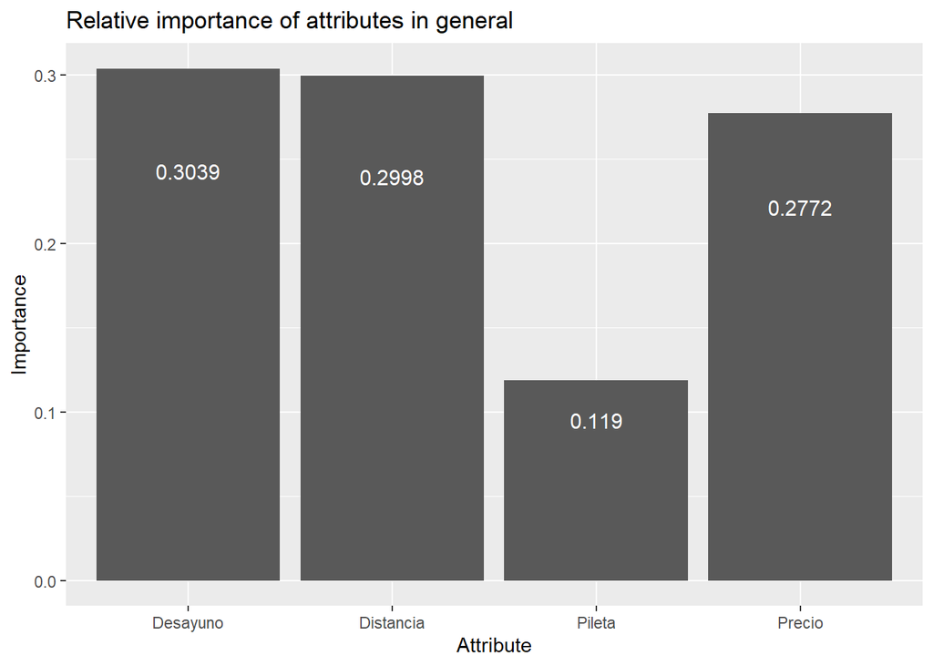

```r
# Plot them together
graf
```

El desayuno es el atributo relativamente más importante para los consumidores, seguido por la distancia. A la hora de tomar una decisión y definir donde hacer un trade-off entre los atributos y sus niveles para la definición del producto ideal para los consumidores, deberíamos intentar no tocar el atributo más importante. Sin embargo, es importante mencionar nuevamente la diversidad que existe en la importancia relativa de cada uno de los atributos. Veremos más adelante algún tipo de clusterización por dichas características o patrones similares.

**3. Valores parciales asociados al precio de cada encuestado. Implicancias en las decisiones de gestión**

Como vimos en términos generales, al ser el desayuno el atributo más importante, nos interesa saber los valores parciales de cada encuestado asociado al mismo. De esta forma podremos ver cómo cambia la utilidad de una persona cuando cambian los niveles del atributo bajo análisis, en esta oportunidad para el caso del precio.

Recordemos que el valor base que tomamos inicialmente fue de $25.000 pesos, por lo que en el ploteo saldrá con valor 0.

Veamos a continuación las distintas visualizaciones para cada individuo y finalmente una genérica:

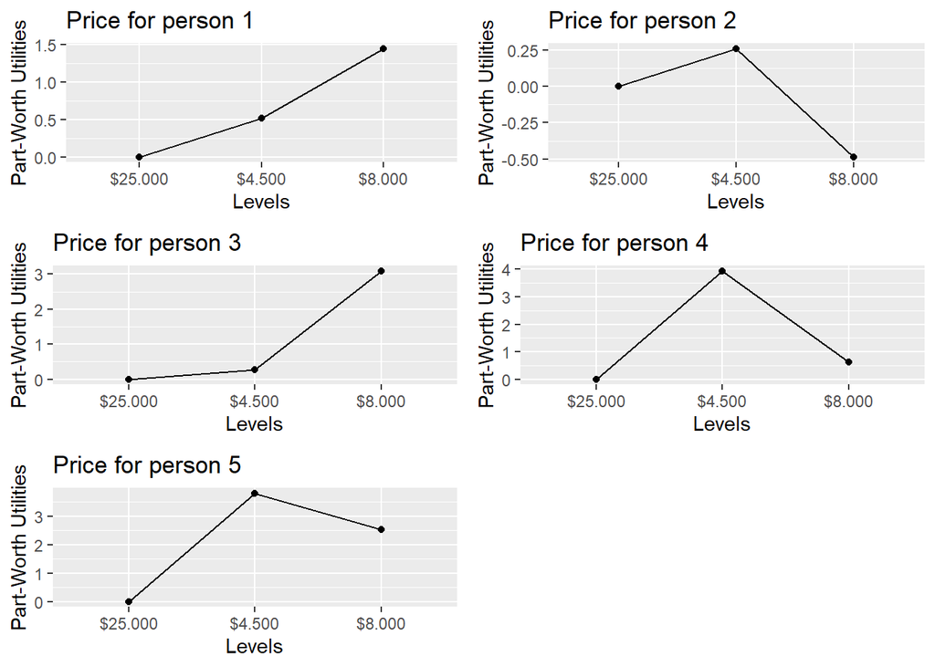

```r
# Plot them together
grid.arrange(gg1,gg2,gg3,gg4,gg5)
```

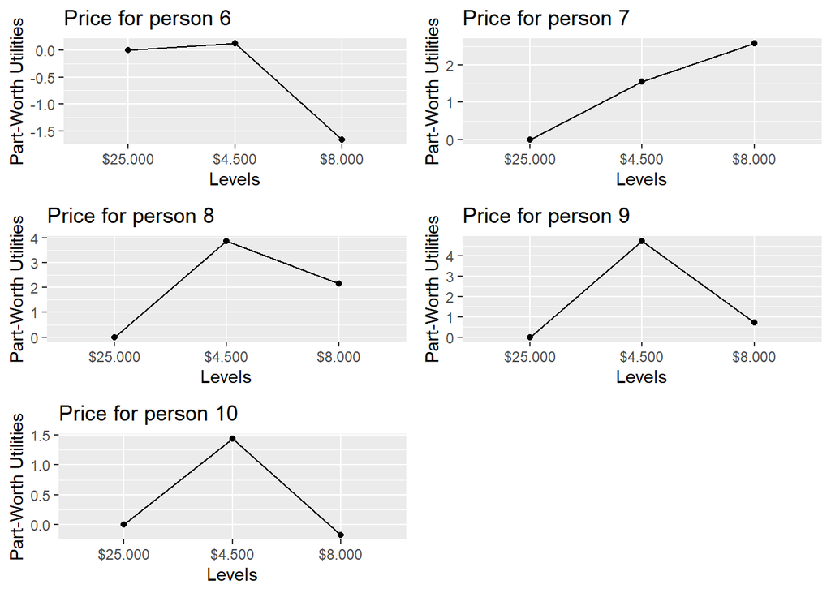

```r
grid.arrange(gg6,gg7,gg8,gg9,gg10)
```

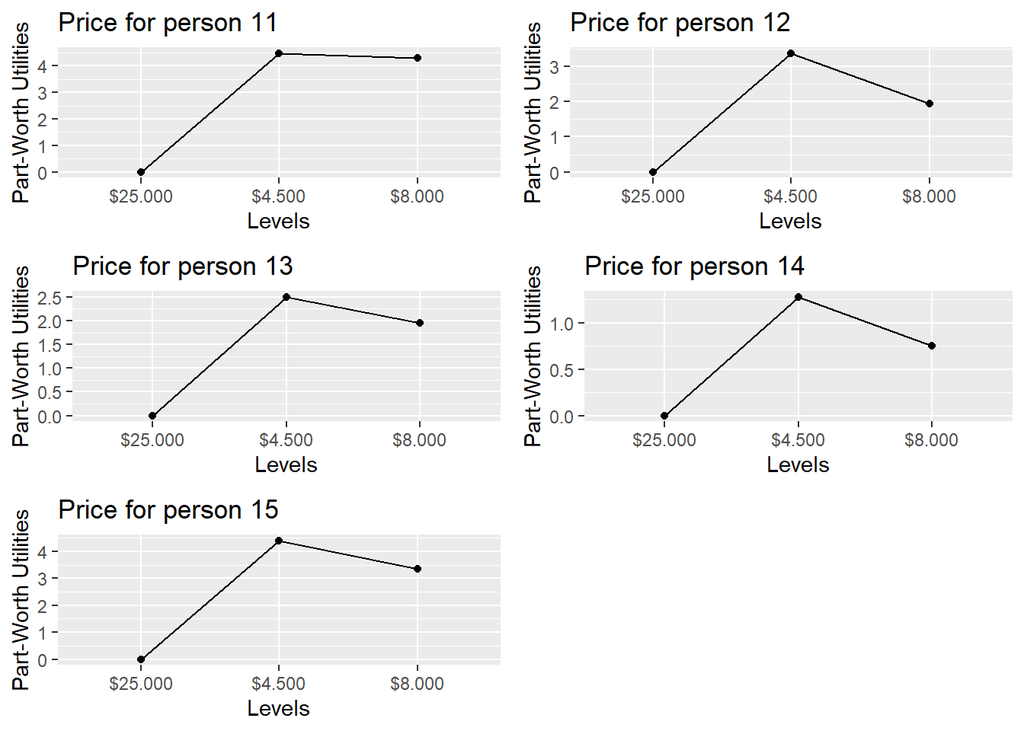

```r
grid.arrange(gg11,gg12,gg13,gg14,gg15)
```

A priori, suponiendo todos los consumidores totalmente racionales, es de esperarse que al aumentar el precio de un producto la utilidad sufra una caída, que tome una relación negativa frente al precio. Aun así, podemos ver que, para ciertos casos, algunos encuestados están dispuestos a pagar $8.000 y esto les da mayor utilidad que pagar $4.500. Una hipótesis interesante de este comportamiento podría ser que los consumidores que sí o sí quieren un hospedaje que incluya desayuno, están dispuestos a pagar más porque en caso contraría lo estarían viendo como un costo.

Podemos ver que en la mayoría de los gráficos se observa esta relación negativa entre utilidad y precio. Para ver cómo se comportan los 47 encuestados se corrió para todo el dataset, resultando la siguiente salida:

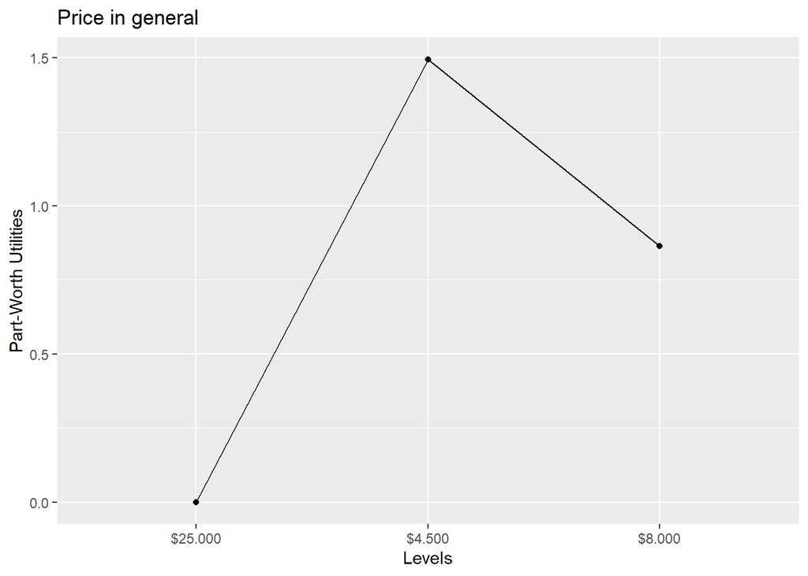

```r
# Plot them together
gg
```

Otra de las implicancias de estos gráficos en las decisiones de gestión es que varios consumidores están dispuestos a pagar $8.000 por sobre $4.500, posiblemente porque ponderan más la inclusión del desayuno en el servicio de hospedaje (ejemplos de este comportamiento puede observarse en el encuestado número 1 y 3).

**4. ¿Cuánto están dispuestos a pagar los consumidores por cambios en el atributo más importante?**

A nivel total de encuestados, recordemos que el atributo principal es el desayuno, seguido de la distancia. En este caso, se intentará determinar el valor monetario que están dispuestos a pagar los consumidores por un cambio en el atributo más importante, es decir, el desayuno.

```r
# General ####
# To be able to plot the part-worth utilities, we will create a table with the relevant information
# We will keep the estimated coefficients (part-worth utilities)
coeffs <- as.vector(summary(linear_model)$coefficients[,1])
# To graph the part-worth utilities we must add the reference levels for each attribute (which have a zero value)
pw_ut <- c(coeffs[1], coeffs[2:3], 0, coeffs[4:5], 0, coeffs[6], 0, coeffs[7], 0)
# Define the levels
levels <- c("Intercept", "$4.500", "$8.000", "$25.000", "0km", "5km", "20km", "Incluye", "No incluye", "Incluye", "No incluye")
# Define the attributes
attributes <- c("Intercept", rep(c("Precio"), times = 3), rep(c("Distancia"), times = 3) ,
                rep(c("Desayuno"), times = 2), rep(c("Pileta"), times = 2))
# Create the part-worth utilities dataframe
pw_ut_df <- data.frame(Variable = attributes, Levels = levels, pw_ut)

# Get the subset of the dataframe for each attribue
data_precio <- subset(pw_ut_df, pw_ut_df$Variable == "Precio")
data_distancia <- subset(pw_ut_df, pw_ut_df$Variable == "Distancia")


lowPrice <- 4500
mediumPrice <- 8000
highPrice <- 25000
# La utilidad relativa de cambiar un hospedaje sin desayuno por uno con desayuno es:
desayuno_ut_range <- data_desayuno$pw_ut[data_desayuno$Levels == "Incluye"] - data_desayuno$pw_ut[data_desayuno$Levels == "No incluye"]    # 1.639493
# El rango de precios es
price_range <- highPrice - lowPrice
# El rango de la utilidad relativa del precio es:
price_ut_range <- data_precio$pw_ut[data_precio$Levels == "$4.500"] - data_precio$pw_ut[data_precio$Levels == "$25.000"]   # 1.495577
# El valor monetario de una unidad de utilidad es:
mv <- price_range / price_ut_range
# Entonces, cambiar de TLC a Provoleta da utilidad relativa de de 1.639493 y el consumidor promedio estaría dispuesto a pagar
wtp <- mv*desayuno_ut_range # $22.472,67
```

Podemos afirmar, que los consumidores están dispuestos a pagar $22.472,67 más si el hospedaje incluye desayuno. Véase el código correspondiente en el botón Code en la parte superior derecha.

**5. Segmentación de clientes utilizando K-means Cluster Analysis.**

A la hora de poder llevar esta idea e investigación a un caso concreto de inversión o negocio, es importante poder determinar el segmento al cual queremos enfocarnos. Como vimos en las regresiones, y en la significatividad de atributos para cada encuestado, la misma arroja una variedad de respuestas y preferencias muy alta que sería difícil de cubrir por solo una propueta.

En ese sentido, se propone utilizar un análisis de cluster con el algoritmo de clasificación no supervisada (clusterización) **Kmeans**. Dicha herramienta nos permite comparar las salidas de las regresiones individuales y poder agrupar a los consumidores en clúster según su comportamiento recolectado por la encuesta.

Los beneficios que nos traerá será poder distinguir nuestros clientes según lo que valoran más, poder ofrecerles ofertas altamente personalizadas a sus gustos y de esa manera obtener un incremento en el Life Time Value del consumidor en nuestra cartera.

Los beneficios asociados al consumidor son los de recibir una propuesta de valor con un nivel personalizado alto, que aumenta la experiencia con el producto y aumenta la lealtad y retención del mismo por un mayor plazo de tiempo.

Desde el punto de vista de negocio, una vez que está la segmentación lista se revisa y se controla algunos aspectos puntuales como los siguientes: 1. Que los segmentos tengan un tamaño adecuado – por lo general se usan 3 segmentos. 2. Identificar los clientes de cada segmento. 3. Que podamos llegar a ellos. Ofertas personalizadas. 4. Que respondan de manera diferente. 5. Que la segmentación sea coherente. 6. Que la segmentación sea estable. Es esencial para mantener una buena estrategia de marketing.

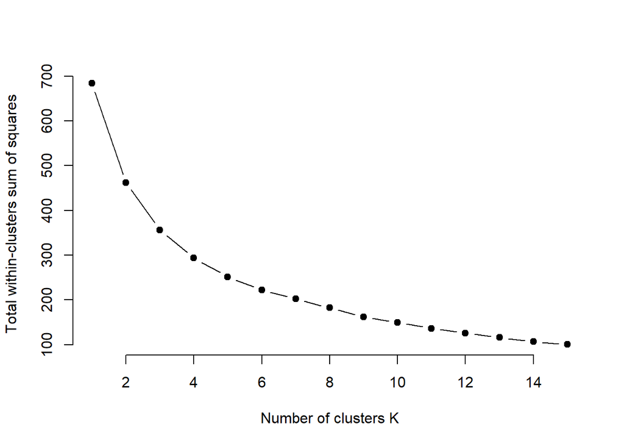

```r
library(tidyverse)  # data manipulation
library(cluster)    # clustering algorithms
library(factoextra) # clustering algorithms & visualization


set.seed(123)

# function to compute total within-cluster sum of square
wss <- function(k) {
  kmeans(dataframe_coeficientes, k, nstart = 10 )$tot.withinss
}

# Compute and plot wss for k = 1 to k = 15
k.values <- 1:15

# extract wss for 2-15 clusters
wss_values <- map_dbl(k.values, wss)

grafkmeans <- plot(k.values, wss_values,
     type="b", pch = 19, frame = FALSE,
     xlab="Number of clusters K",
     ylab="Total within-clusters sum of squares") # tomamos un k=4
```

```r
set.seed(1)
clusters <- kmeans(dataframe_coeficientes, centers=4)

graf_kmeans2 <-fviz_cluster(clusters, data = dataframe_coeficientes)

clusters <- as.data.frame(clusters$cluster)
#write.xlsx(clusters, "clusters.xlsx")
```

Tomando como referencia el primer gráfico, si bien parece no ser tan claro la cantidad de clústers a tomar, se ha decidido utilizar 4 debido a que representaba el menor error en comparación a otras opciones (2 y 3 clústers).

```r
grafkmeans
```

A continuación se puede visualizar la clasificación a un cluster correspondiente a cada encuestado, primero en forma gráfica y luego en forma de lista:

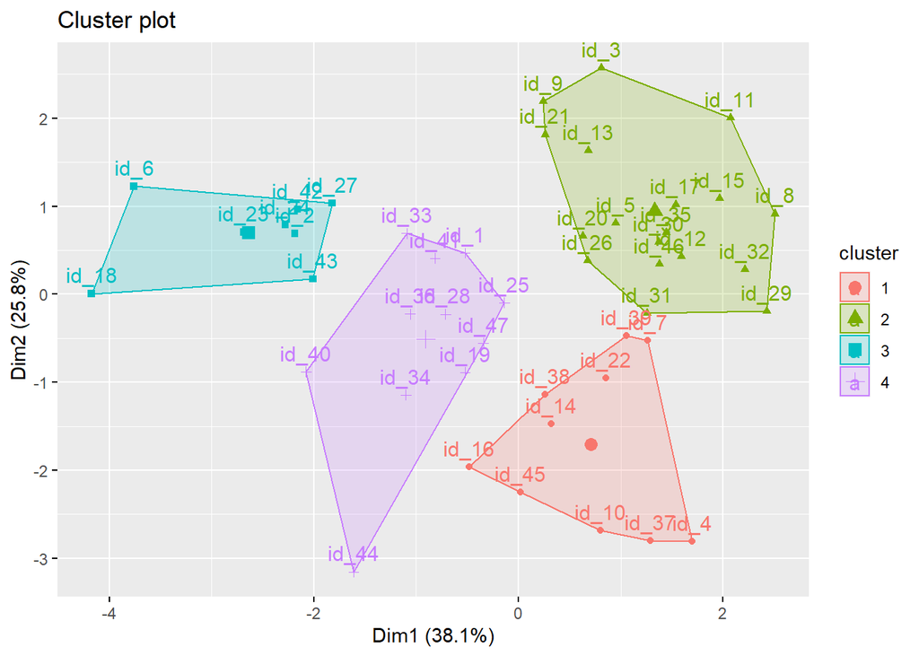

```r
graf_kmeans2
```

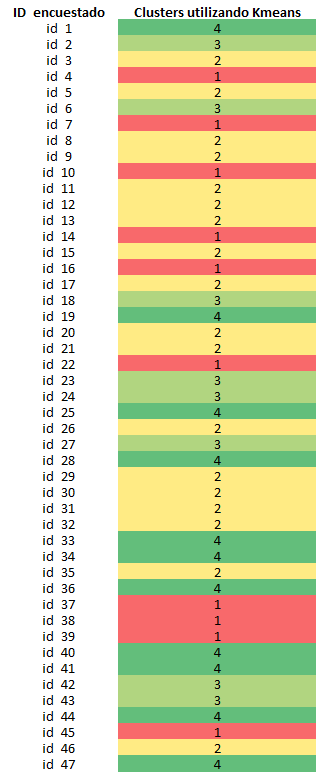

Ahora bien, con dicho análisis de clustering lo que podríamos ver es la características o patrones comunes que el algoritmo está detectando. Las mismas quedan representadas a modo de resumen en el siguiente esquema, tomando también la cantidad de coeficientes significativos existentes en cada grupo y una breve descripción de qué es lo que más valoran los consumidores.

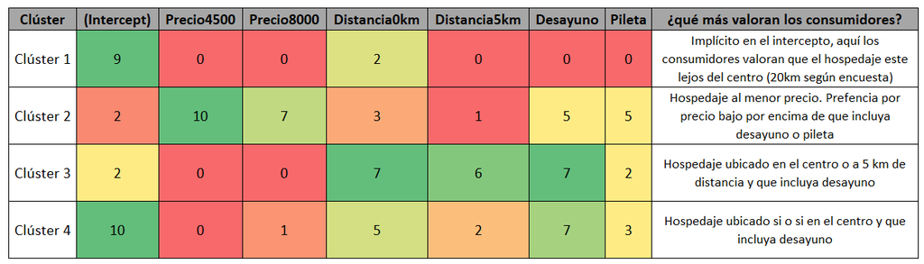

Como conclusión de dicho análisis tendremos 4 posibles estrategias óptimas como desafío de negocio. En primer lugar, un servicio de hospedaje alejado del centro para el primer clúster, seguido de un servicio a bajo precio para el segundo, uno más enfocado en la menor distancia y en el desayuno para el tercero. Y finalmente, un servicio de hospedaje que si o si se encuentre en el centro e incluya desayuno. Es importante notar que si bien el clúster 3 y 4 parecen compartir ciertos patrones, el 3 es más elástico o está dispuesto a sacrificar más a la distancia que el 4.

**6. Análisis de Market Share.**

Para este punto se ha generado dos perfiles de productos que no aparecían en la encuesta. En base a esto, y suponiendo que actualmente éstos son los únicos productos en el mercado ofrecidos por los competidores X e Y, se procedió a estimar cuál sería el market share para cada uno de estos productos.

Los dos productos son:

**a):** - **Precio por noche por persona:** $25.000 - **Ubicación del centro:** 0 km - **Incluye desayuno:** si - **Incluye pileta:** si

**b):** - **Precio por noche por persona:** $8.000 - **Ubicación del centro:** 5 km - **Incluye desayuno:** si - **Incluye pileta:** no

```r
# Punto 6) ####
# General:####
# The utility of a product is the sum of the utilities of its attributes levels

utility_a <- sum(pw_ut_df$pw_ut[pw_ut_df$Levels == "Intercept"] + pw_ut_df$pw_ut[pw_ut_df$Levels == "$25.000"]
                 + pw_ut_df$pw_ut[pw_ut_df$Levels == "0km"] + pw_ut_df$pw_ut[pw_ut_df$Levels == "Incluye"]
                 + pw_ut_df$pw_ut[pw_ut_df$Levels == "Incluye"])

utility_b <-  sum(pw_ut_df$pw_ut[pw_ut_df$Levels == "Intercept"] + pw_ut_df$pw_ut[pw_ut_df$Levels == "$8.000"]
                  + pw_ut_df$pw_ut[pw_ut_df$Levels == "5km"] + pw_ut_df$pw_ut[pw_ut_df$Levels == "Incluye"]
                  + pw_ut_df$pw_ut[pw_ut_df$Levels == "No incluye"])

# Ind1:####
# The utility of a product is the sum of the utilities of its attributes levels

utility_a1 <- sum(pw_ut_df$pw_ut[pw_ut_df$Levels == "Intercept"] + pw_ut_df$pw_ut[pw_ut_df$Levels == "$25.000"]
                 + pw_ut_df$pw_ut[pw_ut_df$Levels == "0km"] + pw_ut_df$pw_ut[pw_ut_df$Levels == "Incluye"]
                 + pw_ut_df$pw_ut[pw_ut_df$Levels == "Incluye"])

utility_b1 <-  sum(pw_ut_df$pw_ut[pw_ut_df$Levels == "Intercept"] + pw_ut_df$pw_ut[pw_ut_df$Levels == "$8.000"]
                  + pw_ut_df$pw_ut[pw_ut_df$Levels == "5km"] + pw_ut_df$pw_ut[pw_ut_df$Levels == "Incluye"]
                  + pw_ut_df$pw_ut[pw_ut_df$Levels == "No incluye"])

# Ind2:####
# The utility of a product is the sum of the utilities of its attributes levels

utility_a2 <- sum(pw_ut_df$pw_ut[pw_ut_df$Levels == "Intercept"] + pw_ut_df$pw_ut[pw_ut_df$Levels == "$25.000"]
                 + pw_ut_df$pw_ut[pw_ut_df$Levels == "0km"] + pw_ut_df$pw_ut[pw_ut_df$Levels == "Incluye"]
                 + pw_ut_df$pw_ut[pw_ut_df$Levels == "Incluye"])

utility_b2 <-  sum(pw_ut_df$pw_ut[pw_ut_df$Levels == "Intercept"] + pw_ut_df$pw_ut[pw_ut_df$Levels == "$8.000"]
                  + pw_ut_df$pw_ut[pw_ut_df$Levels == "5km"] + pw_ut_df$pw_ut[pw_ut_df$Levels == "Incluye"]
                  + pw_ut_df$pw_ut[pw_ut_df$Levels == "No incluye"])

# Ind3:####
# The utility of a product is the sum of the utilities of its attributes levels

utility_a3 <- sum(pw_ut_df$pw_ut[pw_ut_df$Levels == "Intercept"] + pw_ut_df$pw_ut[pw_ut_df$Levels == "$25.000"]
                 + pw_ut_df$pw_ut[pw_ut_df$Levels == "0km"] + pw_ut_df$pw_ut[pw_ut_df$Levels == "Incluye"]
                 + pw_ut_df$pw_ut[pw_ut_df$Levels == "Incluye"])

utility_b3 <-  sum(pw_ut_df$pw_ut[pw_ut_df$Levels == "Intercept"] + pw_ut_df$pw_ut[pw_ut_df$Levels == "$8.000"]
                  + pw_ut_df$pw_ut[pw_ut_df$Levels == "5km"] + pw_ut_df$pw_ut[pw_ut_df$Levels == "Incluye"]
                  + pw_ut_df$pw_ut[pw_ut_df$Levels == "No incluye"])

# Ind4:####
# The utility of a product is the sum of the utilities of its attributes levels

utility_a4 <- sum(pw_ut_df$pw_ut[pw_ut_df$Levels == "Intercept"] + pw_ut_df$pw_ut[pw_ut_df$Levels == "$25.000"]
                 + pw_ut_df$pw_ut[pw_ut_df$Levels == "0km"] + pw_ut_df$pw_ut[pw_ut_df$Levels == "Incluye"]
                 + pw_ut_df$pw_ut[pw_ut_df$Levels == "Incluye"])

utility_b4 <-  sum(pw_ut_df$pw_ut[pw_ut_df$Levels == "Intercept"] + pw_ut_df$pw_ut[pw_ut_df$Levels == "$8.000"]
                  + pw_ut_df$pw_ut[pw_ut_df$Levels == "5km"] + pw_ut_df$pw_ut[pw_ut_df$Levels == "Incluye"]
                  + pw_ut_df$pw_ut[pw_ut_df$Levels == "No incluye"])

# Ind5:####
# The utility of a product is the sum of the utilities of its attributes levels

utility_a5 <- sum(pw_ut_df$pw_ut[pw_ut_df$Levels == "Intercept"] + pw_ut_df$pw_ut[pw_ut_df$Levels == "$25.000"]
                 + pw_ut_df$pw_ut[pw_ut_df$Levels == "0km"] + pw_ut_df$pw_ut[pw_ut_df$Levels == "Incluye"]
                 + pw_ut_df$pw_ut[pw_ut_df$Levels == "Incluye"])

utility_b5 <-  sum(pw_ut_df$pw_ut[pw_ut_df$Levels == "Intercept"] + pw_ut_df$pw_ut[pw_ut_df$Levels == "$8.000"]
                  + pw_ut_df$pw_ut[pw_ut_df$Levels == "5km"] + pw_ut_df$pw_ut[pw_ut_df$Levels == "Incluye"]
                  + pw_ut_df$pw_ut[pw_ut_df$Levels == "No incluye"])

# Ind6:####
# The utility of a product is the sum of the utilities of its attributes levels

utility_a6 <- sum(pw_ut_df$pw_ut[pw_ut_df$Levels == "Intercept"] + pw_ut_df$pw_ut[pw_ut_df$Levels == "$25.000"]
                 + pw_ut_df$pw_ut[pw_ut_df$Levels == "0km"] + pw_ut_df$pw_ut[pw_ut_df$Levels == "Incluye"]
                 + pw_ut_df$pw_ut[pw_ut_df$Levels == "Incluye"])

utility_b6 <-  sum(pw_ut_df$pw_ut[pw_ut_df$Levels == "Intercept"] + pw_ut_df$pw_ut[pw_ut_df$Levels == "$8.000"]
                  + pw_ut_df$pw_ut[pw_ut_df$Levels == "5km"] + pw_ut_df$pw_ut[pw_ut_df$Levels == "Incluye"]
                  + pw_ut_df$pw_ut[pw_ut_df$Levels == "No incluye"])

# Ind7:####
# The utility of a product is the sum of the utilities of its attributes levels

utility_a7 <- sum(pw_ut_df$pw_ut[pw_ut_df$Levels == "Intercept"] + pw_ut_df$pw_ut[pw_ut_df$Levels == "$25.000"]
                 + pw_ut_df$pw_ut[pw_ut_df$Levels == "0km"] + pw_ut_df$pw_ut[pw_ut_df$Levels == "Incluye"]
                 + pw_ut_df$pw_ut[pw_ut_df$Levels == "Incluye"])

utility_b7 <-  sum(pw_ut_df$pw_ut[pw_ut_df$Levels == "Intercept"] + pw_ut_df$pw_ut[pw_ut_df$Levels == "$8.000"]
                  + pw_ut_df$pw_ut[pw_ut_df$Levels == "5km"] + pw_ut_df$pw_ut[pw_ut_df$Levels == "Incluye"]
                  + pw_ut_df$pw_ut[pw_ut_df$Levels == "No incluye"])

# Ind8:####
# The utility of a product is the sum of the utilities of its attributes levels

utility_a8 <- sum(pw_ut_df$pw_ut[pw_ut_df$Levels == "Intercept"] + pw_ut_df$pw_ut[pw_ut_df$Levels == "$25.000"]
                 + pw_ut_df$pw_ut[pw_ut_df$Levels == "0km"] + pw_ut_df$pw_ut[pw_ut_df$Levels == "Incluye"]
                 + pw_ut_df$pw_ut[pw_ut_df$Levels == "Incluye"])

utility_b8 <-  sum(pw_ut_df$pw_ut[pw_ut_df$Levels == "Intercept"] + pw_ut_df$pw_ut[pw_ut_df$Levels == "$8.000"]
                  + pw_ut_df$pw_ut[pw_ut_df$Levels == "5km"] + pw_ut_df$pw_ut[pw_ut_df$Levels == "Incluye"]
                  + pw_ut_df$pw_ut[pw_ut_df$Levels == "No incluye"])

# Ind9:####
# The utility of a product is the sum of the utilities of its attributes levels

utility_a9 <- sum(pw_ut_df$pw_ut[pw_ut_df$Levels == "Intercept"] + pw_ut_df$pw_ut[pw_ut_df$Levels == "$25.000"]
                 + pw_ut_df$pw_ut[pw_ut_df$Levels == "0km"] + pw_ut_df$pw_ut[pw_ut_df$Levels == "Incluye"]
                 + pw_ut_df$pw_ut[pw_ut_df$Levels == "Incluye"])

utility_b9 <-  sum(pw_ut_df$pw_ut[pw_ut_df$Levels == "Intercept"] + pw_ut_df$pw_ut[pw_ut_df$Levels == "$8.000"]
                  + pw_ut_df$pw_ut[pw_ut_df$Levels == "5km"] + pw_ut_df$pw_ut[pw_ut_df$Levels == "Incluye"]
                  + pw_ut_df$pw_ut[pw_ut_df$Levels == "No incluye"])

# Ind10:####
# The utility of a product is the sum of the utilities of its attributes levels

utility_a10 <- sum(pw_ut_df$pw_ut[pw_ut_df$Levels == "Intercept"] + pw_ut_df$pw_ut[pw_ut_df$Levels == "$25.000"]
                 + pw_ut_df$pw_ut[pw_ut_df$Levels == "0km"] + pw_ut_df$pw_ut[pw_ut_df$Levels == "Incluye"]
                 + pw_ut_df$pw_ut[pw_ut_df$Levels == "Incluye"])

utility_b10 <-  sum(pw_ut_df$pw_ut[pw_ut_df$Levels == "Intercept"] + pw_ut_df$pw_ut[pw_ut_df$Levels == "$8.000"]
                  + pw_ut_df$pw_ut[pw_ut_df$Levels == "5km"] + pw_ut_df$pw_ut[pw_ut_df$Levels == "Incluye"]
                  + pw_ut_df$pw_ut[pw_ut_df$Levels == "No incluye"])

# Ind11:####
# The utility of a product is the sum of the utilities of its attributes levels

utility_a11 <- sum(pw_ut_df$pw_ut[pw_ut_df$Levels == "Intercept"] + pw_ut_df$pw_ut[pw_ut_df$Levels == "$25.000"]
                 + pw_ut_df$pw_ut[pw_ut_df$Levels == "0km"] + pw_ut_df$pw_ut[pw_ut_df$Levels == "Incluye"]
                 + pw_ut_df$pw_ut[pw_ut_df$Levels == "Incluye"])

utility_b11 <-  sum(pw_ut_df$pw_ut[pw_ut_df$Levels == "Intercept"] + pw_ut_df$pw_ut[pw_ut_df$Levels == "$8.000"]
                  + pw_ut_df$pw_ut[pw_ut_df$Levels == "5km"] + pw_ut_df$pw_ut[pw_ut_df$Levels == "Incluye"]
                  + pw_ut_df$pw_ut[pw_ut_df$Levels == "No incluye"])

# Ind12:####
# The utility of a product is the sum of the utilities of its attributes levels

utility_a12 <- sum(pw_ut_df$pw_ut[pw_ut_df$Levels == "Intercept"] + pw_ut_df$pw_ut[pw_ut_df$Levels == "$25.000"]
                 + pw_ut_df$pw_ut[pw_ut_df$Levels == "0km"] + pw_ut_df$pw_ut[pw_ut_df$Levels == "Incluye"]
                 + pw_ut_df$pw_ut[pw_ut_df$Levels == "Incluye"])

utility_b12 <-  sum(pw_ut_df$pw_ut[pw_ut_df$Levels == "Intercept"] + pw_ut_df$pw_ut[pw_ut_df$Levels == "$8.000"]
                  + pw_ut_df$pw_ut[pw_ut_df$Levels == "5km"] + pw_ut_df$pw_ut[pw_ut_df$Levels == "Incluye"]
                  + pw_ut_df$pw_ut[pw_ut_df$Levels == "No incluye"])

# Ind13:####
# The utility of a product is the sum of the utilities of its attributes levels

utility_a13 <- sum(pw_ut_df$pw_ut[pw_ut_df$Levels == "Intercept"] + pw_ut_df$pw_ut[pw_ut_df$Levels == "$25.000"]
                 + pw_ut_df$pw_ut[pw_ut_df$Levels == "0km"] + pw_ut_df$pw_ut[pw_ut_df$Levels == "Incluye"]
                 + pw_ut_df$pw_ut[pw_ut_df$Levels == "Incluye"])

utility_b13 <-  sum(pw_ut_df$pw_ut[pw_ut_df$Levels == "Intercept"] + pw_ut_df$pw_ut[pw_ut_df$Levels == "$8.000"]
                  + pw_ut_df$pw_ut[pw_ut_df$Levels == "5km"] + pw_ut_df$pw_ut[pw_ut_df$Levels == "Incluye"]
                  + pw_ut_df$pw_ut[pw_ut_df$Levels == "No incluye"])

# Ind14:####
# The utility of a product is the sum of the utilities of its attributes levels

utility_a14 <- sum(pw_ut_df$pw_ut[pw_ut_df$Levels == "Intercept"] + pw_ut_df$pw_ut[pw_ut_df$Levels == "$25.000"]
                 + pw_ut_df$pw_ut[pw_ut_df$Levels == "0km"] + pw_ut_df$pw_ut[pw_ut_df$Levels == "Incluye"]
                 + pw_ut_df$pw_ut[pw_ut_df$Levels == "Incluye"])

utility_b14 <-  sum(pw_ut_df$pw_ut[pw_ut_df$Levels == "Intercept"] + pw_ut_df$pw_ut[pw_ut_df$Levels == "$8.000"]
                  + pw_ut_df$pw_ut[pw_ut_df$Levels == "5km"] + pw_ut_df$pw_ut[pw_ut_df$Levels == "Incluye"]
                  + pw_ut_df$pw_ut[pw_ut_df$Levels == "No incluye"])

# Ind15:####
# The utility of a product is the sum of the utilities of its attributes levels

utility_a15 <- sum(pw_ut_df$pw_ut[pw_ut_df$Levels == "Intercept"] + pw_ut_df$pw_ut[pw_ut_df$Levels == "$25.000"]
                 + pw_ut_df$pw_ut[pw_ut_df$Levels == "0km"] + pw_ut_df$pw_ut[pw_ut_df$Levels == "Incluye"]
                 + pw_ut_df$pw_ut[pw_ut_df$Levels == "Incluye"])

utility_b15 <-  sum(pw_ut_df$pw_ut[pw_ut_df$Levels == "Intercept"] + pw_ut_df$pw_ut[pw_ut_df$Levels == "$8.000"]
                  + pw_ut_df$pw_ut[pw_ut_df$Levels == "5km"] + pw_ut_df$pw_ut[pw_ut_df$Levels == "Incluye"]
                  + pw_ut_df$pw_ut[pw_ut_df$Levels == "No incluye"])




utilidades_a <- rbind(utility_a1,utility_a2,utility_a3,utility_a4,utility_a5,utility_a6,utility_a7,utility_a8,utility_a9,utility_a10,utility_a11,utility_a12,utility_a13,utility_a14,utility_a15)
utilidades_b <- rbind(utility_b1,utility_b2,utility_b3,utility_b4,utility_b5,utility_b6,utility_b7,utility_b8,utility_b9,utility_b10,utility_b11,utility_b12,utility_b13,utility_b14,utility_b15)

utilidades_a <- as.data.frame(utilidades_a)
utilidades_b <- as.data.frame(utilidades_b)

#write.xlsx(utilidades_a, "utilidades_a.xlsx")
#write.xlsx(utilidades_b, "utilidades_b.xlsx")
```

A continuación se detallan los resultados obtenidos para los primeros 15 encuestados:

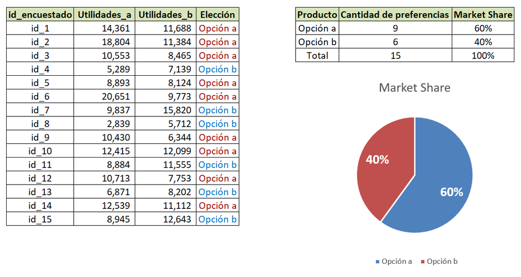

Como se puede observar, la opción a es superior en términos de utilidad para los consumidores que la opción b.